# **Capstone Project : Natural Language Processing Chatbot Interface Interim Solution**

## Problem Statement

**• DOMAIN:** Industrial safety. NLP based Chatbot.

**• CONTEXT:** The database comes from one of the biggest industry in Brazil and in the world. It is an urgent need for industries/companies around the globe to understand why employees still suffer some injuries/accidents in plants. Sometimes they also die in such environment.

**• DATA DESCRIPTION:** This The database is basically records of accidents from 12 different plants in 03 different countries which every line in the data is an occurrence of an accident.

**Columns description:**

**‣ Data:** timestamp or time/date information

**‣ Countries:** which country the accident occurred (anonymised)

**‣ Local:** the city where the manufacturing plant is located (anonymised)

**‣ Industry sector:** which sector the plant belongs to

**‣ Accident level:** from I to VI, it registers how severe was the accident (I means not severe but VI means very severe)

**‣ Potential Accident_Level:** Depending on the Accident_Level, the database also registers how severe the accident could have been (due to other factors involved in the accident)

**‣ Genre:** if the person is male of female

**‣ Employee or Third Party:** if the injured person is an employee or a third party

**‣ Critical Risk:** some description of the risk involved in the accident

**‣ Description:** Detailed description of how the accident happened.

Link to download the dataset: https://www.kaggle.com/ihmstefanini/industrial-safety-and-health-analytics-database [ for your reference only ]

**• PROJECT OBJECTIVE:**

Design a ML/DL based chatbot utility which can help the professionals to highlight the safety risk as per the incident description.

**• PROJECT TASK: [ Score: 100 points]**

**1. Milestone 1:** [ Score: 40 points ]

**‣ Input:** Context and Dataset

**‣ Process:**

**‣** Step 1: Import the data [ 3 points ]

**‣** Step 2: Data cleansing [ 5 points ]

**‣** Step 3: Data preprocessing (NLP Preprocessing techniques) [ 7 points ]

**‣** Step 4: Data preparation - Cleansed data in .xlsx or .csv file [ 5 points ]

**‣** Step 5: Design train and test basic machine learning classifiers [ 10 Points ]

**‣** Step 6: Interim report [ 10 points ]

**2. Milestone 2:** [ Score: 60 points ] **‣ Input:** Preprocessed output from Milestone-1

**‣ Process:**

**‣** Step 1: Design, train and test Neural networks classifiers [ 5 points ]

**‣** Step 2: Design, train and test RNN or LSTM classifiers [ 10 points ]

**‣** Step 3: Choose the best performing classifier and pickle it. [ 5 points ]

**‣** Step 4: Final Report [40 Points]

**‣ Submission:** Final report, Jupyter Notebook with all the steps in Milestone-1 and Milestone-2

**3. Milestone 3:** [ Optional ]

**‣ Process:**

**‣** Step 1: Design a clickable UI based chatbot interface

**‣ Submission:** Final report, Jupyter Notebook with the addition of clickable UI based interface

**‣** Hints:

**‣** Please refer to the blog to understand the basic designing and functioning of chatbots: https://www.mygreatlearning.com/blog/basicsof- building-an-artificial-intelligence-chatbot/

**‣** To make GUI as a desk app you can use TKINTER library.

**‣** To make web service GUI you can use FLASK or DJANGO library.

**NOTE:** Only Milestone 1 solution will be provided in this Interim

## **Importing Necessary Libraries**

```python
# downgrading sci-kit learn to avoid sklearn tags error(as below) for XGBoost
# 'super' object has no attribute '__sklearn_tags__'.
!pip uninstall -y scikit-learn
!pip install scikit-learn==1.3.1
```

```
Found existing installation: scikit-learn 1.6.1
Uninstalling scikit-learn-1.6.1:
  Successfully uninstalled scikit-learn-1.6.1
Downloading scikit_learn-1.3.1-cp311-cp311-manylinux_2_17_x86_64.manylinux2014_x86_64.whl (10.9 MB)
   ━━━━━━━━━━━━━━━━━━━━━━━━━━━━━━━━━━━━━━━━ 10.9/10.9 MB 86.4 MB/s eta 0:00:00
ERROR: pip's dependency resolver does not currently take into account all the packages that are installed. This behaviour is the source of the following dependency conflicts.
imbalanced-learn 0.13.0 requires scikit-learn<2,>=1.3.2, but you have scikit-learn 1.3.1 which is incompatible.
```

```python
# To read and manipulate the data
import pandas as pd
import numpy as np

pd.set_option('max_colwidth', 500)    # setting column to the maximum column width as per the data

# to ignore unnecessary warnings
import warnings
warnings.filterwarnings("ignore")

import random
import itertools
import matplotlib.cm as cm # to use a colormap to create a gradient effect in plots

# to visualise data
import matplotlib.pyplot as plt
%matplotlib inline
import seaborn as sns

# to use regular expressions for manipulating text data
import re


# to load the natural language toolkit
import nltk

#nltk.download('stopwords')    # loading the stopwords
#nltk.download('wordnet')    # loading the wordnet module that is used in stemming
#nltk.download('punkt_tab')
#nltk.download('averaged_perceptron_tagger_eng')

# to remove common stop words
from nltk.corpus import stopwords,wordnet
from nltk.stem import WordNetLemmatizer
from nltk import pos_tag
from wordcloud import WordCloud, STOPWORDS
from nltk.tokenize import word_tokenize

#for plotting word cloud
from wordcloud import WordCloud

from gensim.models import Word2Vec, KeyedVectors
from sklearn.feature_extraction.text import TfidfVectorizer

# Deep Learning library
import torch

# to load transformer models
from sentence_transformers import SentenceTransformer



# to split the data
from sklearn.model_selection import (train_test_split,StratifiedKFold,
                                     cross_val_score,GridSearchCV)

# to compute performance metrics
from sklearn.metrics import (confusion_matrix, classification_report, accuracy_score,
                             roc_curve, precision_score, recall_score, f1_score,
                             roc_auc_score, ConfusionMatrixDisplay)

#for model building
from sklearn.linear_model import LogisticRegression
from sklearn.svm import SVC
from sklearn.tree import DecisionTreeClassifier
from sklearn.ensemble import RandomForestClassifier
from xgboost import XGBClassifier


# build pipeline
from sklearn.impute import SimpleImputer
from sklearn.preprocessing import OrdinalEncoder,StandardScaler
from sklearn.pipeline import Pipeline
from sklearn.compose import ColumnTransformer,make_column_selector, make_column_transformer
```

```python
nltk.download('stopwords')
nltk.download('wordnet')
nltk.download('punkt')
nltk.download('punkt_tab')
nltk.download('averaged_perceptron_tagger');
nltk.download('averaged_perceptron_tagger_eng')
```

```
True
```

```python
from google.colab import drive
drive.mount('/content/drive') # Mounting Google Drive to access the dataset
```

## **Loading and Reading Data**

```python
accidents_df = pd.read_excel("/content/drive/My Drive/Capstone/data/Data_Set_industrial_safety_and_health_database_with_accidents_description.xlsx")
df = accidents_df.copy()
```

```python
df.rename(columns = {'Data':'Date','Countries':'Country','Local':'City','Industry Sector':'Industry_Sector','Accident Level':'Accident_Level','Potential Accident Level':'Potential_Accident_Level','Genre':'Gender','Employee or Third Party':'Employee_Type','Critical Risk':'Critical_Risk'}, inplace = True)
```

```python
def detailed_summary(df):

  '''
    Print a summary of the given dataframe to display no of records, columns,
    datatype and names of each column.
    Also list the Missing values, Duplicate values, if any along with other details


  '''

  print(f'Data set has {df.shape[0]} rows and {df.shape[1]} columns')
  print(f'Various datatypes present in the dataset are:\n{df.dtypes.value_counts()}')
  summary = pd.DataFrame(df.dtypes, columns = ['Datatypes'])
  summary = summary.reset_index()
  summary['Missing_values'] = df.isnull().sum().values
  summary['Unique_values'] = df.nunique().values
  summary['Duplicate_values'] = df.duplicated().sum()
  summary['First_value'] = df.loc[0].values
  summary['Second_value'] = df.loc[1].values
  return summary
```

### Initial Summary

```python
detailed_summary(df)
```

```
Data set has 425 rows and 11 columns
Various datatypes present in the dataset are:
object            9
int64             1
datetime64[ns]    1
Name: count, dtype: int64
```

|  | index | Datatypes | Missing_values | Unique_values | Duplicate_values | First_value | Second_value |
| --- | --- | --- | --- | --- | --- | --- | --- |
| 0 | Unnamed: 0 | int64 | 0 | 425 | 0 | 0 | 1 |
| 1 | Date | datetime64[ns] | 0 | 287 | 0 | 2016-01-01 00:00:00 | 2016-01-02 00:00:00 |
| 2 | Country | object | 0 | 3 | 0 | Country_01 | Country_02 |
| 3 | City | object | 0 | 12 | 0 | Local_01 | Local_02 |
| 4 | Industry_Sector | object | 0 | 3 | 0 | Mining | Mining |
| 5 | Accident_Level | object | 0 | 5 | 0 | I | I |
| 6 | Potential_Accident_Level | object | 0 | 6 | 0 | IV | IV |
| 7 | Gender | object | 0 | 2 | 0 | Male | Male |
| 8 | Employee_Type | object | 0 | 3 | 0 | Third Party | Employee |
| 9 | Critical_Risk | object | 0 | 33 | 0 | Pressed | Pressurized Systems |
| 10 | Description | object | 0 | 411 | 0 | While removing the drill rod of the Jumbo 08 for maintenance, the supervisor proceeds to loosen the support of the intermediate centralizer to facilitate the removal, seeing this the mechanic supports… | During the activation of a sodium sulphide pump, the piping was uncoupled and the sulfide solution was designed in the area to reach the maid. Immediately she made use of the emergency shower and was … |

```python
#drop first column as it has unique values(more like an index)
df.drop('Unnamed: 0',axis=1,inplace=True)
```

```python
detailed_summary(df)
```

```
Data set has 425 rows and 10 columns
Various datatypes present in the dataset are:
object            9
datetime64[ns]    1
Name: count, dtype: int64
```

|  | index | Datatypes | Missing_values | Unique_values | Duplicate_values | First_value | Second_value |
| --- | --- | --- | --- | --- | --- | --- | --- |
| 0 | Date | datetime64[ns] | 0 | 287 | 7 | 2016-01-01 00:00:00 | 2016-01-02 00:00:00 |
| 1 | Country | object | 0 | 3 | 7 | Country_01 | Country_02 |
| 2 | City | object | 0 | 12 | 7 | Local_01 | Local_02 |
| 3 | Industry_Sector | object | 0 | 3 | 7 | Mining | Mining |
| 4 | Accident_Level | object | 0 | 5 | 7 | I | I |
| 5 | Potential_Accident_Level | object | 0 | 6 | 7 | IV | IV |
| 6 | Gender | object | 0 | 2 | 7 | Male | Male |
| 7 | Employee_Type | object | 0 | 3 | 7 | Third Party | Employee |
| 8 | Critical_Risk | object | 0 | 33 | 7 | Pressed | Pressurized Systems |
| 9 | Description | object | 0 | 411 | 7 | While removing the drill rod of the Jumbo 08 for maintenance, the supervisor proceeds to loosen the support of the intermediate centralizer to facilitate the removal, seeing this the mechanic supports… | During the activation of a sodium sulphide pump, the piping was uncoupled and the sulfide solution was designed in the area to reach the maid. Immediately she made use of the emergency shower and was … |

### Check duplicates across all columns

```python
df[df.duplicated(keep=False)]
```

|  | Date | Country | City | Industry_Sector | Accident_Level | Potential_Accident_Level | Gender | Employee_Type | Critical_Risk | Description |
| --- | --- | --- | --- | --- | --- | --- | --- | --- | --- | --- |
| 76 | 2016-04-01 | Country_01 | Local_01 | Mining | I | V | Male | Third Party (Remote) | Others | In circumstances that two workers of the Abratech company were doing putty work inside the conditioning tank (5 meters deep and covered by platforms) of metal gratings - grating- in the upper part), t… |
| 77 | 2016-04-01 | Country_01 | Local_01 | Mining | I | V | Male | Third Party (Remote) | Others | In circumstances that two workers of the Abratech company were doing putty work inside the conditioning tank (5 meters deep and covered by platforms) of metal gratings - grating- in the upper part), t… |
| 261 | 2016-12-01 | Country_01 | Local_03 | Mining | I | IV | Male | Employee | Others | During the activity of chuteo of ore in hopper OP5; the operator of the locomotive parks his equipment under the hopper to fill the first car, it is at this moment that when it was blowing out to rele… |
| 262 | 2016-12-01 | Country_01 | Local_03 | Mining | I | IV | Male | Employee | Others | During the activity of chuteo of ore in hopper OP5; the operator of the locomotive parks his equipment under the hopper to fill the first car, it is at this moment that when it was blowing out to rele… |
| 302 | 2017-01-21 | Country_02 | Local_02 | Mining | I | I | Male | Third Party (Remote) | Others | Employees engaged in the removal of material from the excavation of the well 2 of level 265, using shovel and placing it in the bucket. During the day some of this material fell into the pipes of the … |
| 303 | 2017-01-21 | Country_02 | Local_02 | Mining | I | I | Male | Third Party (Remote) | Others | Employees engaged in the removal of material from the excavation of the well 2 of level 265, using shovel and placing it in the bucket. During the day some of this material fell into the pipes of the … |
| 344 | 2017-03-02 | Country_03 | Local_10 | Others | I | I | Male | Third Party | Venomous Animals | On 02/03/17 during the soil sampling in the region of Sta. the employees Rafael and Danillo da Silva were attacked by a bee test. They rushed away from the place, but the employee Rafael took 4 bites,… |
| 345 | 2017-03-02 | Country_03 | Local_10 | Others | I | I | Male | Third Party | Venomous Animals | On 02/03/17 during the soil sampling in the region of Sta. the employees Rafael and Danillo da Silva were attacked by a bee test. They rushed away from the place, but the employee Rafael took 4 bites,… |
| 346 | 2017-03-02 | Country_03 | Local_10 | Others | I | I | Male | Third Party | Venomous Animals | On 02/03/17 during the soil sampling in the region of Sta. the employees Rafael and Danillo da Silva were attacked by a bee test. They rushed away from the place, but the employee Rafael took 4 bites,… |
| 354 | 2017-03-15 | Country_03 | Local_10 | Others | I | I | Male | Third Party | Venomous Animals | Team of the VMS Project performed soil collection on the Xixás target with 3 members. When the teams were moving from one collection point to another, Mr. Fabio was ahead of the team, stinging behind … |
| 355 | 2017-03-15 | Country_03 | Local_10 | Others | I | I | Male | Third Party | Venomous Animals | Team of the VMS Project performed soil collection on the Xixás target with 3 members. When the teams were moving from one collection point to another, Mr. Fabio was ahead of the team, stinging behind … |
| 396 | 2017-05-23 | Country_01 | Local_04 | Mining | I | IV | Male | Third Party | Projection of fragments | In moments when the 02 collaborators carried out the inspection of the conveyor belt No. 3 from the tail pulley when they were at the height of the load polymer No. 372, the Maslucan collaborator hear… |
| 397 | 2017-05-23 | Country_01 | Local_04 | Mining | I | IV | Male | Third Party | Projection of fragments | In moments when the 02 collaborators carried out the inspection of the conveyor belt No. 3 from the tail pulley when they were at the height of the load polymer No. 372, the Maslucan collaborator hear… |

```python
#Drop the duplicate 7 rows
df.drop_duplicates(inplace=True)
```

```python
detailed_summary(df)
```

```
Data set has 418 rows and 10 columns
Various datatypes present in the dataset are:
object            9
datetime64[ns]    1
Name: count, dtype: int64
```

|  | index | Datatypes | Missing_values | Unique_values | Duplicate_values | First_value | Second_value |
| --- | --- | --- | --- | --- | --- | --- | --- |
| 0 | Date | datetime64[ns] | 0 | 287 | 0 | 2016-01-01 00:00:00 | 2016-01-02 00:00:00 |
| 1 | Country | object | 0 | 3 | 0 | Country_01 | Country_02 |
| 2 | City | object | 0 | 12 | 0 | Local_01 | Local_02 |
| 3 | Industry_Sector | object | 0 | 3 | 0 | Mining | Mining |
| 4 | Accident_Level | object | 0 | 5 | 0 | I | I |
| 5 | Potential_Accident_Level | object | 0 | 6 | 0 | IV | IV |
| 6 | Gender | object | 0 | 2 | 0 | Male | Male |
| 7 | Employee_Type | object | 0 | 3 | 0 | Third Party | Employee |
| 8 | Critical_Risk | object | 0 | 33 | 0 | Pressed | Pressurized Systems |
| 9 | Description | object | 0 | 411 | 0 | While removing the drill rod of the Jumbo 08 for maintenance, the supervisor proceeds to loosen the support of the intermediate centralizer to facilitate the removal, seeing this the mechanic supports… | During the activation of a sodium sulphide pump, the piping was uncoupled and the sulfide solution was designed in the area to reach the maid. Immediately she made use of the emergency shower and was … |

```python
df[df.duplicated("Description",keep=False)].sort_values('Description')
```

|  | Date | Country | City | Industry_Sector | Accident_Level | Potential_Accident_Level | Gender | Employee_Type | Critical_Risk | Description |
| --- | --- | --- | --- | --- | --- | --- | --- | --- | --- | --- |
| 166 | 2016-07-07 | Country_01 | Local_03 | Mining | IV | V | Male | Third Party | Others | At moments when the MAPERU truck of plate F1T 878, returned from the city of Pasco to the Unit transporting a consultant, being 350 meters from the main gate his lane is invaded by a civilian vehicle,… |
| 167 | 2016-07-07 | Country_01 | Local_03 | Mining | I | IV | Male | Third Party | Others | At moments when the MAPERU truck of plate F1T 878, returned from the city of Pasco to the Unit transporting a consultant, being 350 meters from the main gate his lane is invaded by a civilian vehicle,… |
| 261 | 2016-12-01 | Country_01 | Local_03 | Mining | I | IV | Male | Employee | Others | During the activity of chuteo of ore in hopper OP5; the operator of the locomotive parks his equipment under the hopper to fill the first car, it is at this moment that when it was blowing out to rele… |
| 263 | 2016-12-01 | Country_01 | Local_03 | Mining | I | IV | Male | Third Party | Others | During the activity of chuteo of ore in hopper OP5; the operator of the locomotive parks his equipment under the hopper to fill the first car, it is at this moment that when it was blowing out to rele… |
| 412 | 2017-06-20 | Country_01 | Local_01 | Mining | I | IV | Male | Employee | Others | In circumstance, the AHK-903 license plate (Empresa which serves the supervision of CMA, carried out the field inspections in the upper bank 4288, when unexpectedly when climbing through the operation… |
| 413 | 2017-06-20 | Country_01 | Local_01 | Mining | I | IV | Male | Third Party | Others | In circumstance, the AHK-903 license plate (Empresa which serves the supervision of CMA, carried out the field inspections in the upper bank 4288, when unexpectedly when climbing through the operation… |
| 130 | 2016-05-26 | Country_03 | Local_10 | Others | I | I | Male | Third Party | Bees | In the geological reconnaissance activity, in the farm of Mr. Lázaro, the team composed by Felipe and Divino de Morais, in normal activity encountered a ciliary forest, as they needed to enter the for… |
| 131 | 2016-05-26 | Country_03 | Local_10 | Others | I | I | Male | Employee | Others | In the geological reconnaissance activity, in the farm of Mr. Lázaro, the team composed by Felipe and Divino de Morais, in normal activity encountered a ciliary forest, as they needed to enter the for… |
| 143 | 2016-06-08 | Country_03 | Local_10 | Others | I | I | Male | Third Party | Bees | Project of Vazante that carried out sediment collection of current in the South of Mata target, in the drainage of Serra do Garrote. team that was composed of 04 members of the WCA company, being the … |
| 144 | 2016-06-08 | Country_03 | Local_10 | Others | I | I | Male | Third Party | Others | Project of Vazante that carried out sediment collection of current in the South of Mata target, in the drainage of Serra do Garrote. team that was composed of 04 members of the WCA company, being the … |
| 387 | 2017-05-06 | Country_02 | Local_07 | Mining | IV | V | Male | Employee | Projection | The employees Márcio and Sérgio performed the pump pipe clearing activity FZ1.031.4 and during the removal of the suction spool flange bolts, there was projection of pulp over them causing injuries. |
| 388 | 2017-05-06 | Country_02 | Local_07 | Mining | II | V | Male | Employee | Projection | The employees Márcio and Sérgio performed the pump pipe clearing activity FZ1.031.4 and during the removal of the suction spool flange bolts, there was projection of pulp over them causing injuries. |
| 37 | 2016-02-24 | Country_02 | Local_07 | Mining | I | V | Male | Employee | Others | When starting the activity of removing a coil of electric cables in the warehouse with the help of forklift truck the operator did not notice that there was a beehive in it. Due to the movement of the… |
| 38 | 2016-02-24 | Country_02 | Local_07 | Mining | I | V | Female | Third Party | Others | When starting the activity of removing a coil of electric cables in the warehouse with the help of forklift truck the operator did not notice that there was a beehive in it. Due to the movement of the… |

```python
df.drop_duplicates('Description', keep='first', inplace=True)
```

```python
detailed_summary(df)
```

```
Data set has 411 rows and 10 columns
Various datatypes present in the dataset are:
object            9
datetime64[ns]    1
Name: count, dtype: int64
```

|  | index | Datatypes | Missing_values | Unique_values | Duplicate_values | First_value | Second_value |
| --- | --- | --- | --- | --- | --- | --- | --- |
| 0 | Date | datetime64[ns] | 0 | 287 | 0 | 2016-01-01 00:00:00 | 2016-01-02 00:00:00 |
| 1 | Country | object | 0 | 3 | 0 | Country_01 | Country_02 |
| 2 | City | object | 0 | 12 | 0 | Local_01 | Local_02 |
| 3 | Industry_Sector | object | 0 | 3 | 0 | Mining | Mining |
| 4 | Accident_Level | object | 0 | 5 | 0 | I | I |
| 5 | Potential_Accident_Level | object | 0 | 6 | 0 | IV | IV |
| 6 | Gender | object | 0 | 2 | 0 | Male | Male |
| 7 | Employee_Type | object | 0 | 3 | 0 | Third Party | Employee |
| 8 | Critical_Risk | object | 0 | 33 | 0 | Pressed | Pressurized Systems |
| 9 | Description | object | 0 | 411 | 0 | While removing the drill rod of the Jumbo 08 for maintenance, the supervisor proceeds to loosen the support of the intermediate centralizer to facilitate the removal, seeing this the mechanic supports… | During the activation of a sodium sulphide pump, the piping was uncoupled and the sulfide solution was designed in the area to reach the maid. Immediately she made use of the emergency shower and was … |

### Unique values

```python
cat_cols = list(df.select_dtypes('object').columns)
cat_cols.remove('Description')
for c in cat_cols:
    print('*'*70)
    print(df[c].value_counts())
```

```
Country
Country_01    245
Country_02    127
Country_03     39
Name: count, dtype: int64
City
Local_03    87
Local_05    59
Local_04    55
Local_01    55
Local_06    46
Local_10    39
Local_08    27
Local_02    23
Local_07    12
Local_12     4
Local_09     2
Local_11     2
Name: count, dtype: int64
Industry_Sector
Mining    232
Metals    134
Others     45
Name: count, dtype: int64
Accident_Level
I      303
II      39
III     31
IV      30
V        8
Name: count, dtype: int64
Potential_Accident_Level
IV     138
III    106
II      95
I       43
V       28
VI       1
Name: count, dtype: int64
Gender
```

[output cut: 28 more lines]

```
Electrical Shock                               2
Machine Protection                             2
Poll                                           1
Confined space                                 1
Electrical installation                        1
\nNot applicable                               1
Plates                                         1
Projection/Burning                             1
Traffic                                        1
Projection/Choco                               1
Burn                                           1
Projection/Manual Tools                        1
Individual protection equipment                1
Projection of fragments                        1
Name: count, dtype: int64
```

```python
#replace Level 6 as Level V as only one record is present at that level
df['Potential_Accident_Level'].replace('VI','V',inplace=True)
```

```python
#Delete the new line character at the beginning of the value
df['Critical_Risk'].replace('\nNot applicable','Not applicable',inplace=True)
```

### **Data Cleaning Key Points**

- There are 425 rows and 11 columns in the dataset initially.
- The First column "Unnamed: 0" was not needed and hence the column was dropped from the dataset.
- The Column names were renamed to proper format
- Except the date column all other columns are of object datatype
- The dataset does not contain any rows or columns with null values or missing values
- In the dataset there are 7 duplicates rows with same information in all the columns - hence dropped these duplicate records
- Now the size of the dataset has reduced from 425 to 418 rows and 10 columns
- Doing a quick unique values of each column in the dataset revealed that the description column has some duplicates in it
- After printing duplicate records based on the Description column - Noticed that there are 7 more columns with duplicate entires in description column and other columns except 1 or 2 columns with different information
- Hence dropped these 7 records from the dataset
- The final Dataset now has 411 Rows and 10 Columns
- Since we have the date of the accident available - we can extract the Year, Month, Day and Day Name from the date columns to new columns and use it for better understanding of the accidents based on the period

### **Data Summary Key Points**

- The dataset contains details of accidents from the years 2016 and 2017
- We have from 3 countries across 12 different locations in the dataset
- The accidents are from 3 Industry_Sectors "MINING", "METALS" and "OTHERS"
- The accident levels range between I to V
- The Potential accident levels range between I to VI
- There is only 1 record for Potential accident level 6 in the dataset. So this will be changed to Level V
- There are 3 employee type in the dataset "Third Party", "Employee" and "Third Party(Remote)"
- 33 different critical risks are available in the critical risk column of the dataset
- Most of the accidents are listed as part of "Others" in the critical risk column

## **Feature Engineering**

#### Extract features from Date

Extracting the Year, Month, Date, Day from the Date Columns and adding these to new columns in the dataset

```python
df['Year'] = df['Date'].dt.year
```

```python
df['Month'] = df['Date'].dt.month
```

```python
df['Day'] = df['Date'].dt.day
```

```python
df['Day_Name'] = df['Date'].dt.day_name()
```

#### Extract feature from Description

Add number of words in Description

```python
# Total length the words present in each news articles and storing in new column "Word_Count"
df['Word_Count'] = df['Description'].apply(lambda x: len(x.split(' ')))
```

## Revised Summary

```python
detailed_summary(df)
```

```
Data set has 411 rows and 15 columns
Various datatypes present in the dataset are:
object            10
int32              3
datetime64[ns]     1
int64              1
Name: count, dtype: int64
```

|  | index | Datatypes | Missing_values | Unique_values | Duplicate_values | First_value | Second_value |
| --- | --- | --- | --- | --- | --- | --- | --- |
| 0 | Date | datetime64[ns] | 0 | 287 | 0 | 2016-01-01 00:00:00 | 2016-01-02 00:00:00 |
| 1 | Country | object | 0 | 3 | 0 | Country_01 | Country_02 |
| 2 | City | object | 0 | 12 | 0 | Local_01 | Local_02 |
| 3 | Industry_Sector | object | 0 | 3 | 0 | Mining | Mining |
| 4 | Accident_Level | object | 0 | 5 | 0 | I | I |
| 5 | Potential_Accident_Level | object | 0 | 5 | 0 | IV | IV |
| 6 | Gender | object | 0 | 2 | 0 | Male | Male |
| 7 | Employee_Type | object | 0 | 3 | 0 | Third Party | Employee |
| 8 | Critical_Risk | object | 0 | 33 | 0 | Pressed | Pressurized Systems |
| 9 | Description | object | 0 | 411 | 0 | While removing the drill rod of the Jumbo 08 for maintenance, the supervisor proceeds to loosen the support of the intermediate centralizer to facilitate the removal, seeing this the mechanic supports… | During the activation of a sodium sulphide pump, the piping was uncoupled and the sulfide solution was designed in the area to reach the maid. Immediately she made use of the emergency shower and was … |
| 10 | Year | int32 | 0 | 2 | 0 | 2016 | 2016 |
| 11 | Month | int32 | 0 | 12 | 0 | 1 | 1 |
| 12 | Day | int32 | 0 | 31 | 0 | 1 | 2 |
| 13 | Day_Name | object | 0 | 7 | 0 | Friday | Saturday |
| 14 | Word_Count | int64 | 0 | 119 | 0 | 80 | 54 |

```python
def plot_countplots_in_loop(df, exclude_cols=['Date','Country','Industry_Sector','Gender',"Employee_Type" 'Description']):
    cols_to_plot = [col for col in df.columns if col not in exclude_cols]
    for col1, col2 in itertools.combinations(cols_to_plot, 2):
        plot_countplot_with_hue(df, col1, col2)
        plot_countplot_with_hue(df, col2, col1)
def plot_countplot_with_hue(df, x_col, hue_col):
    plt.figure(figsize=(15, 5))
    if hue_col in df.columns:
        hue_order = df[hue_col].value_counts().sort_index().index
        ax = sns.countplot(x=x_col, hue=hue_col, data=df, hue_order=hue_order)
    else:
        ax = sns.countplot(x=x_col, data=df)
    plt.title(f'Countplot of {x_col} by {hue_col}')
    plt.xticks(rotation=45, ha='right')
    for p in ax.patches:
        ax.annotate(f'{p.get_height():.0f}', (p.get_x() + p.get_width() / 2., p.get_height()),ha='center', va='center', xytext=(0, 10), textcoords='offset points')
    print("*" * 250)
    plt.show()
#plot_countplots_in_loop(df)
```

```python
df.info()
```

```
<class 'pandas.core.frame.DataFrame'>
Index: 411 entries, 0 to 424
Data columns (total 15 columns):
 #   Column                    Non-Null Count  Dtype
---  ------                    --------------  -----
 0   Date                      411 non-null    datetime64[ns]
 1   Country                   411 non-null    object
 2   City                      411 non-null    object
 3   Industry_Sector           411 non-null    object
 4   Accident_Level            411 non-null    object
 5   Potential_Accident_Level  411 non-null    object
 6   Gender                    411 non-null    object
 7   Employee_Type             411 non-null    object
 8   Critical_Risk             411 non-null    object
 9   Description               411 non-null    object
 10  Year                      411 non-null    int32
 11  Month                     411 non-null    int32
 12  Day                       411 non-null    int32
 13  Day_Name                  411 non-null    object
 14  Word_Count                411 non-null    int64
dtypes: datetime64[ns](1), int32(3), int64(1), object(10)
memory usage: 62.7+ KB
```

## Exploratory Data Analysis

## Univariate Analysis

We will look at the distribution of each individual features using histograms, box plots, stacked bar plots and countplot

```python
#Helper methods
def visualise_continuous_features(df,col,format=False):

    '''
      Draw the histogram and box plot for the given column
      in the given dataframe

    '''

    fig,(ax1,ax2) = plt.subplots(1,2,figsize=(10,3))


    plt.suptitle(f'Distribution of {col} ')


    sns.histplot(df,x=col,ax = ax1,kde=True,color='#c963b1');
    sns.boxplot(df,x=col,ax = ax2,color='#f8ecac',showmeans=True);
```

```python
def visualise_cat_features(df,col):

    '''
      Plots a pie chart if feature has less than 5 unique values
      Plots a countplot if it has >=5 and <=20 unique values
      Prints an error message if it has >20 unique values

    '''

    num_values = df[col].nunique()
    values_count = df[col].value_counts()


    if num_values <= 4:

        #pie
        colors  = ['#8EB897', '#B7C3F3', '#DD7596', '#4F6272' ]
        plt.pie(values_count, labels = values_count.index, colors=colors, autopct='%.2f%%',
              shadow = True, explode = [0.1]*len(values_count.index), startangle = -135)
        plt.title(f"Distribution of {col}")
        plt.show()

    elif num_values <= 20:

        #countplot
        plt.figure(figsize = (12,5))
        ax = sns.countplot(df,x=col,order=values_count.index,palette='Set2')

        # Calculate percentages
        total = len(df[col])

        # Add labels on the bars
        for p in ax.patches:

            count = p.get_height()
            percentage = (count/total) * 100

            # Add count label in the center
            ax.text(p.get_x() + p.get_width()/2.,
                    count/2.,
                    f'{int(count)}',
                    ha='center',
                    va='center')

            # Add percentage label on top
            ax.text(p.get_x() + p.get_width()/2.,
                    count,
                    f'{percentage:.1f}%',
                    ha='center',
                    va='bottom')

        plt.title(f"Distribution of {col}")

    else:
            print('Too many values for visualization')
```

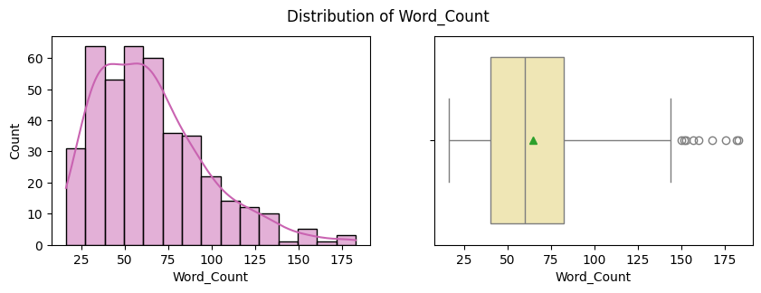

```python
visualise_continuous_features(df,'Word_Count')
```

- Distribution of Word Count is right skewed, indicating most of the descriptions contain fewer than 75 words
- 50% of the descriptions are around 60 words or lesser
- Few descriptions contain more than 150 words

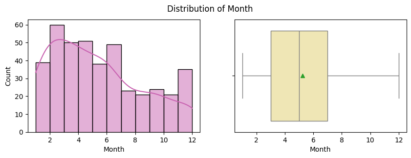

```python
visualise_continuous_features(df,'Month')
```

- The distibution of Month indicates that there seem to be more accidents in the first half of the year. This needs to be validated by looking at the Year column as well

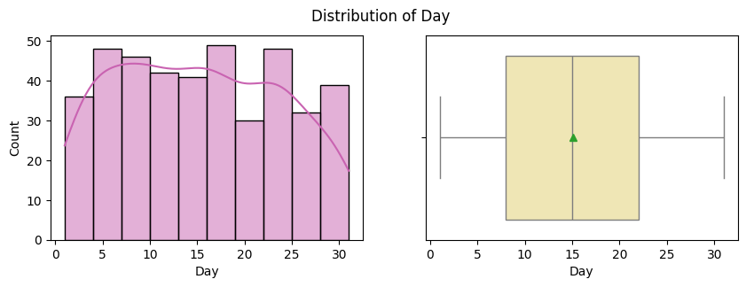

```python
visualise_continuous_features(df,'Day')
```

- Accidents are likely to occur on any Day of the month and hence can be excluded as a feature

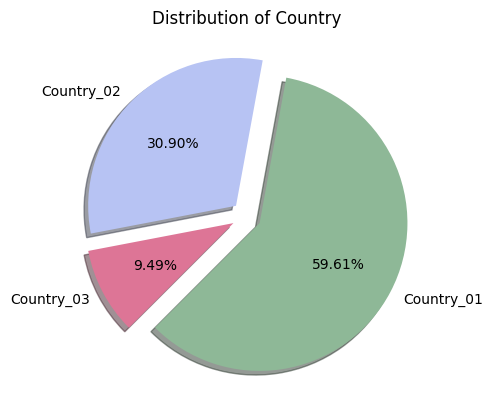

```python
visualise_cat_features(df,'Country')
```

- Country 1 has reported almost 60% of accidents. Probably because there are more cities with industrial plants in this country. This needs to be verified in Bivariate analysis
- Country 2 and Country 3 report approx 30% and 10% accidents respectively

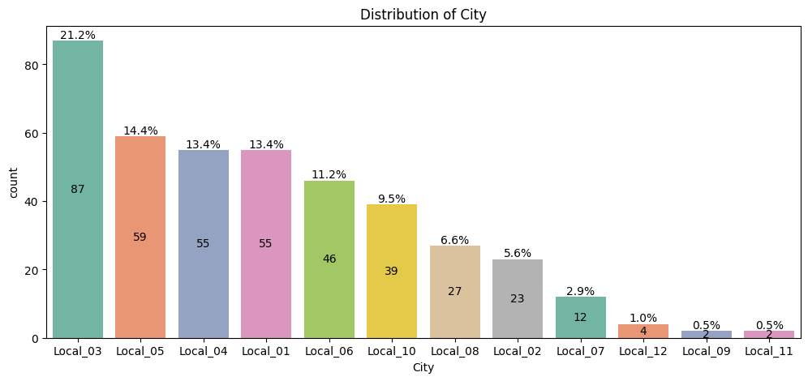

```python
visualise_cat_features(df,'City')
```

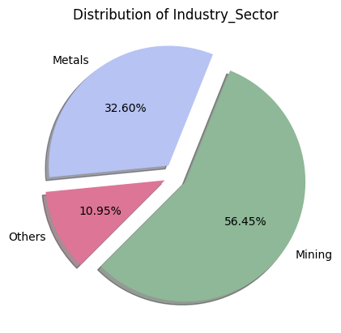

```python
visualise_cat_features(df,'Industry_Sector')
```

- Mining industry contributes to almost 56% accidents
- Metals and Others industries contribute 33% and 11% accidents (approx)

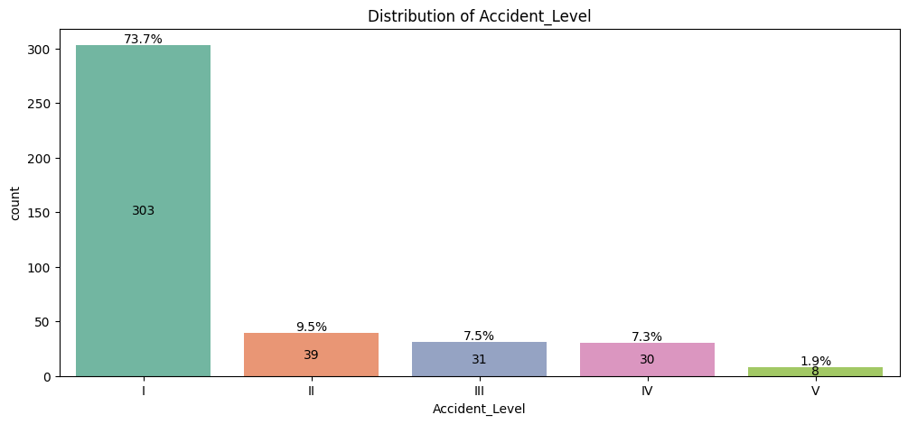

```python
visualise_cat_features(df,'Accident_Level')
```

- 74% of the accidents are categorised as Level I accidents indicating a low severity
- 2% are classified as Level V (most severe)

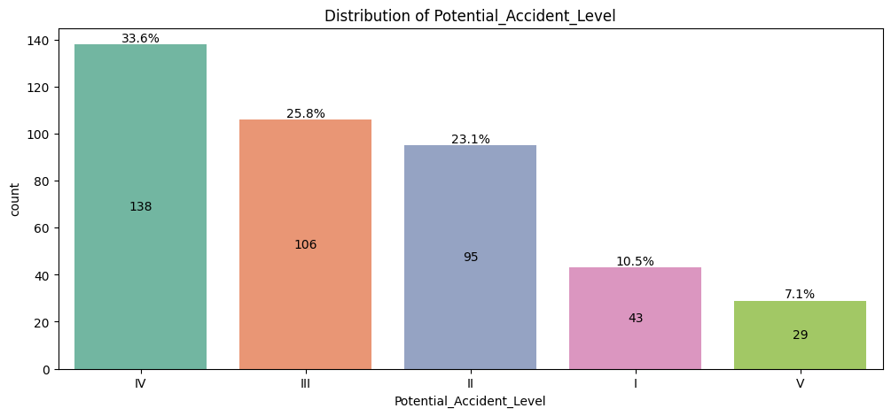

```python
visualise_cat_features(df,'Potential_Accident_Level')
```

- There is a mismatch observed between Accident Level and Potential Accident Level
- Most of the accidents categorised as Level I Accident are of higher severity, this can be seen from the reduced number of Level I accidents according to Potential Accident Level
- This indicates that Potential Accident Level will indicate a better categorisation of accidents as compared to Accident Level and hence a better target for predicting acccident severity

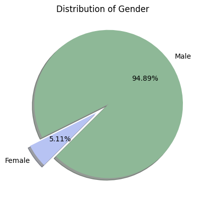

```python
visualise_cat_features(df,'Gender')
```

- 95% employees who reported accidents are Male compared to 5% Females

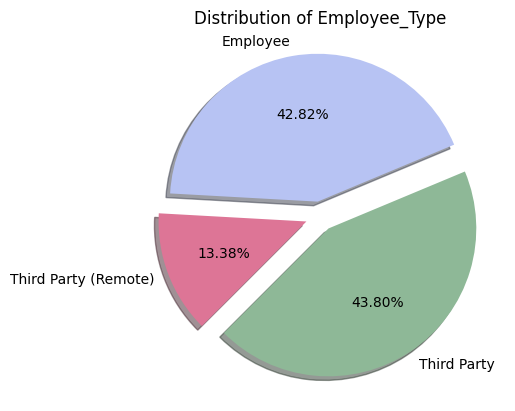

```python
visualise_cat_features(df,'Employee_Type')
```

- 44% of accidents are recorded by Third party (possibly contract) employees
- 43% accidents are recorded by Direct employees
- Least accidents (13%) are recorded by Third Party Remote employees, possibly because they are not working on location in the plants

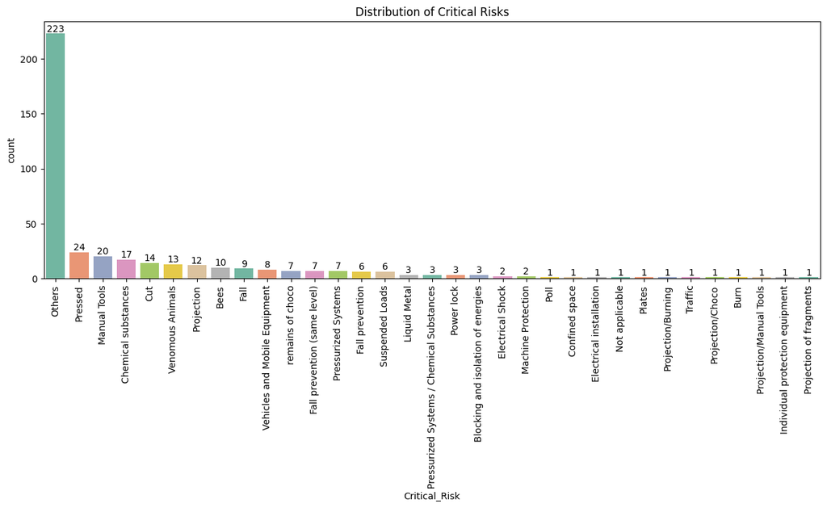

```python
plt.figure(figsize = (15,5))
values_count = df['Critical_Risk'].value_counts().sort_values(ascending=False).index
ax = sns.countplot(df,x='Critical_Risk',palette='Set2',order=values_count)
for c in ax.containers:
    plt.bar_label(c, fmt=lambda x: np.where(x > 0, f'{x:.0f}', ''), label_type='edge')
    plt.xticks(rotation=90)
#values_count.plot(kind='bar')
plt.title(f"Distribution of Critical Risks")
plt.show();
```

- More than 50% of accidents are categorised as Others.
- The other significant critical risks are Pressed, Manual Tools, Chemical Substances, Cut, Venomous Animals, Projection, Bees and Fall

## Multivariate Analysis

We will analyse the relationship between features as below:

- Distribution of all key features against Potential Accident Level
- Yearly distribution of accidents based on Potential Accident Level
- Country wise distribution of accidents against Potential accident level
- Accident Level vs Potential accident level

```python
#Helper method to plot accidents based on given year
def plt_yearly_accidents(df,year):

    year_df = df[df['Year']==year]

    month_accidents = year_df.groupby(['Month','Potential_Accident_Level'])['Potential_Accident_Level'].count()
    accidents_count = month_accidents.to_frame()
    accidents_count.rename({'Potential_Accident_Level':'Count'},axis=1,inplace=True)
    accidents_count
    plt.figure(figsize=(12,6))
    sns.lineplot(data=accidents_count, x="Month", y='Count', hue="Potential_Accident_Level",palette='Set2');
    plt.title(f'Number of accidents in year {year}');
```

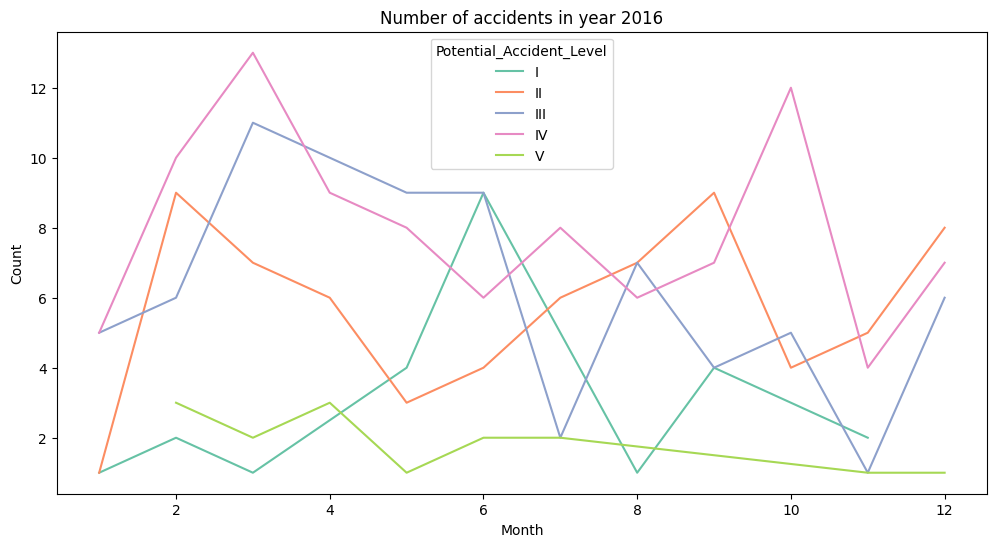

```python
plt_yearly_accidents(df,2016)
```

- The dataset contains accident records for all months in the year 2016
- The maximum number of accidents of a given category was 13 accidents of Level IV in March
- Most severe accidents (Level V) were observed in February and April
- Level IV accidents in March and October
- Least severe accidents (Level I) were observed most in June

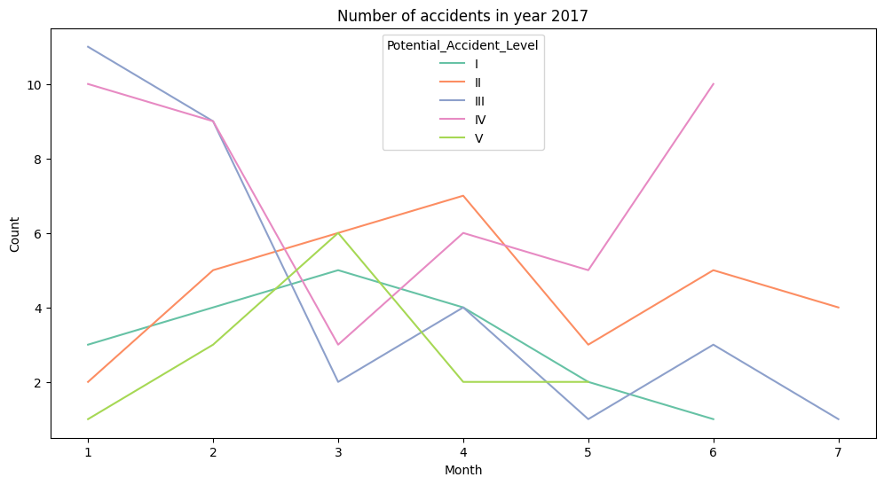

```python
plt_yearly_accidents(df,2017)
```

- The dataset contains accident records for only till July in the year 2017
- There is a decreasing trend for all accident levels except Level IV towards July end
- The maximum number of accidents of a given category was 11 accidents of Level III in January
- Most severe accidents (Level V) were observed in March
- Level IV accidents in January and June
- Least severe accidents (Level I) were observed most in March

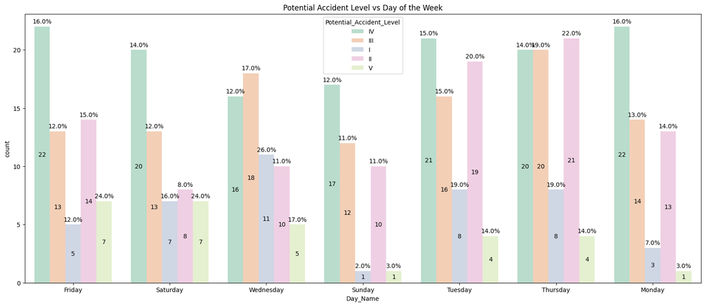

```python
#accidents by Day_Name

plt.figure(figsize=(20,8))
ax = sns.countplot(
    data=df, x="Day_Name", hue="Potential_Accident_Level", palette="Pastel2"
)
# Calculate the total count for each container
totals = []
for container in ax.containers:
    total = 0
    for bar in container:
        total += bar.get_height()
    totals.append(total)

# Add value labels as percentages inside the bar
for i, container in enumerate(ax.containers):
    ax.bar_label(container, fmt=lambda x: np.where(x > 0, f'{x:.0f}', ''), label_type='center')
    for j, bar in enumerate(container):
        ax.annotate(str(round(bar.get_height()/totals[i]*100, 0)) + '%',
                    xy=(bar.get_x() + bar.get_width() / 2, bar.get_height()),
                    xytext=(0, 3),  # 3 points vertical offset
                    textcoords="offset points",
                    ha='center', va='bottom')
plt.title(f'Potential Accident Level vs Day of the Week');
```

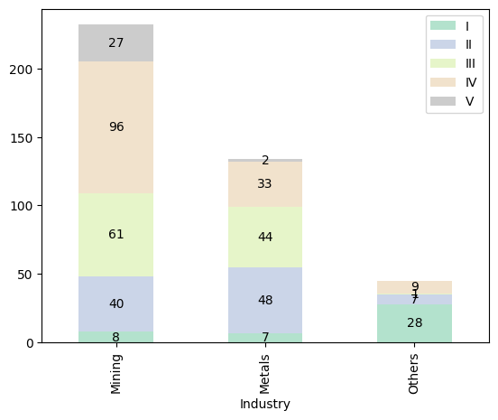

```python
# industry wise distribution of accidents
industries = df['Industry_Sector'].unique()
level1_count,level2_count,level3_count,level4_count,level5_count = [],[],[],[],[]

for val in industries:
    level1_count.append(len(df[(df['Industry_Sector']==val) & (df['Potential_Accident_Level'] == 'I')]))
    level2_count.append(len(df[(df['Industry_Sector']==val) & (df['Potential_Accident_Level'] == 'II')]))
    level3_count.append(len(df[(df['Industry_Sector']==val) & (df['Potential_Accident_Level'] == 'III')]))
    level4_count.append(len(df[(df['Industry_Sector']==val) & (df['Potential_Accident_Level'] == 'IV')]))
    level5_count.append(len(df[(df['Industry_Sector']==val) & (df['Potential_Accident_Level'] == 'V')]))

industry_accidents = pd.DataFrame({
    'Industry':industries,
    'I':level1_count,
    'II':level2_count,
    'III':level3_count,
    'IV':level4_count,
    'V':level5_count,
})

ax = industry_accidents.plot(x = 'Industry', kind='bar', stacked=True,colormap = 'Pastel2')
# Iterating through multiple containers for annotation in complex charts
for c in ax.containers:
    ax.bar_label(c, fmt=lambda x: np.where(x > 0, f'{x:.0f}', ''), label_type='center')
```

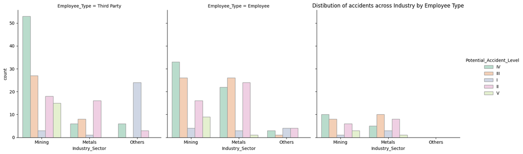

```python
#Industry vs Employee Type vs Potential Accident Level
plt.figure(figsize=(20,8))
ax = sns.catplot(
    data=df, x="Industry_Sector", hue="Potential_Accident_Level", kind='count',
    palette="Pastel2", edgecolor=".6", col = 'Employee_Type'
)
plt.title('Distibution of accidents across Industry by Employee Type');
```

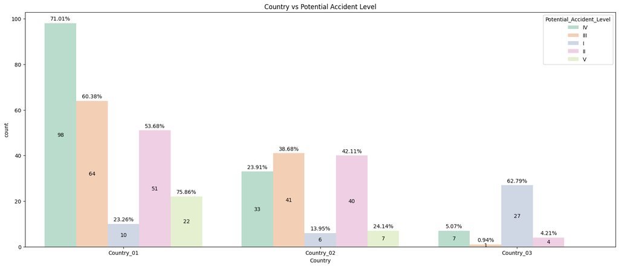

```python
#Country vs Potential Accident Level

plt.figure(figsize=(20,8))
ax = sns.countplot(
    data=df, x="Country", hue="Potential_Accident_Level", palette="Pastel2"
)
# Calculate the total count for each container
totals = []
for container in ax.containers:
    total = 0
    for bar in container:
        total += bar.get_height()
    totals.append(total)

# Add value labels as percentages inside the bar
for i, container in enumerate(ax.containers):
    ax.bar_label(container, fmt=lambda x: np.where(x > 0, f'{x:.0f}', ''), label_type='center')
    for j, bar in enumerate(container):
        ax.annotate(str(round(bar.get_height()/totals[i]*100, 2)) + '%',
                    xy=(bar.get_x() + bar.get_width() / 2, bar.get_height()),
                    xytext=(0, 3),  # 3 points vertical offset
                    textcoords="offset points",
                    ha='center', va='bottom')
plt.title(f'Country vs Potential Accident Level');
```

- Country 1 has reported most accidents with majority of Level IV accidents
- Country 3 has reported the least number of accidents of which most are low severity accidents
- Most severe accidents (Levels IV and V) are reported in Country 1 and Country 2

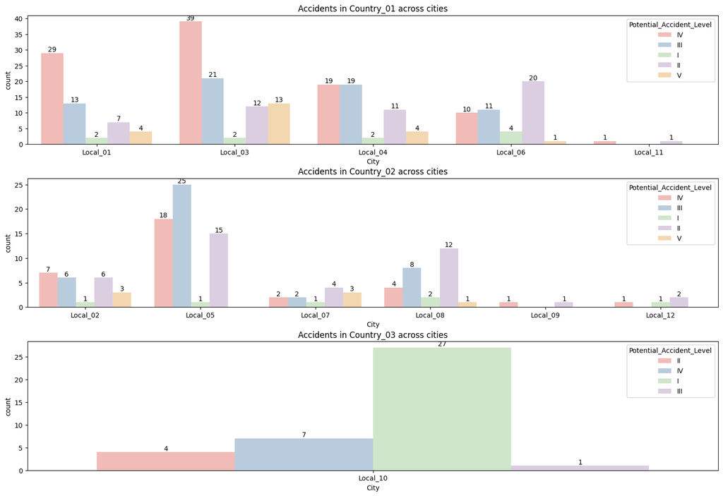

```python
countries = df['Country'].unique()
fig,ax = plt.subplots(3,1,figsize=(15,10))
fig.tight_layout(h_pad=3)
for i,c in enumerate(countries):
    country_df = df[df['Country']==c]
    curr_ax = ax[i]

    sns.countplot(country_df,x='City',hue='Potential_Accident_Level',palette='Pastel1',ax=curr_ax)

    for label in curr_ax.containers:
        curr_ax.bar_label(label, fmt=lambda x: np.where(x > 0, f'{x:.0f}', ''), label_type='edge')

    curr_ax.set_title(f'Accidents in {c} across cities')
```

- Country 1 has plants across 5 cities.
- The plant in Local 3 in Country 1 has reported the most accidents of higher severity (Level IV and 5)
- Country 2 has plants across 6 cities while Country 3 in one city
- Plant in Local 10 in Country 3 has reported the highest number of Level I accidents and has not recorded any accident of Level V
- Country 1 and Country 2 have the least number of Level I (least severe) accidents

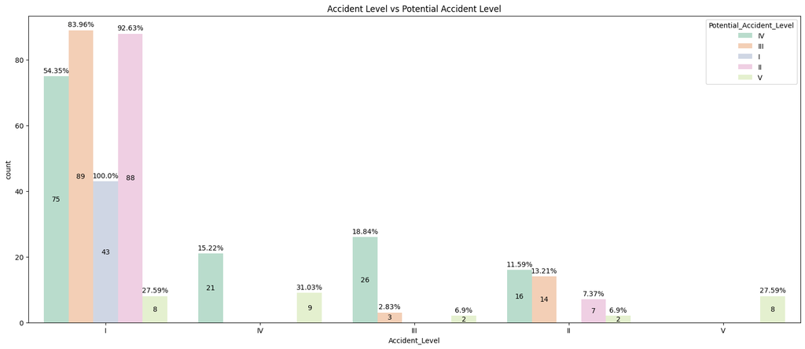

```python
#Accident Level vs Potential Accident Level

plt.figure(figsize=(20,8))
ax = sns.countplot(
    data=df, x="Accident_Level", hue="Potential_Accident_Level", palette="Pastel2"
)
# Calculate the total count for each container
totals = []
for container in ax.containers:
    total = 0
    for bar in container:
        total += bar.get_height()
    totals.append(total)

# Add value labels as percentages inside the bar
for i, container in enumerate(ax.containers):
    ax.bar_label(container, fmt=lambda x: np.where(x > 0, f'{x:.0f}', ''), label_type='center')
    for j, bar in enumerate(container):
        ax.annotate(str(round(bar.get_height()/totals[i]*100, 2)) + '%',
                    xy=(bar.get_x() + bar.get_width() / 2, bar.get_height()),
                    xytext=(0, 3),  # 3 points vertical offset
                    textcoords="offset points",
                    ha='center', va='bottom')
plt.title(f'Accident Level vs Potential Accident Level');
```

- Accident Level tends to categorise accidents on lower severity than Potential Accident Level
- Most of the accidents reported as Level I Accident are actually of a higher severity
- 92% of Potential Accident Level II are categorised as Level I accidents
- 84% of Potential Accident Level III are categorised as Level I accidents
- Only 8 accidents were categorised with highest severity in both Accident Level and Potential Accident Level

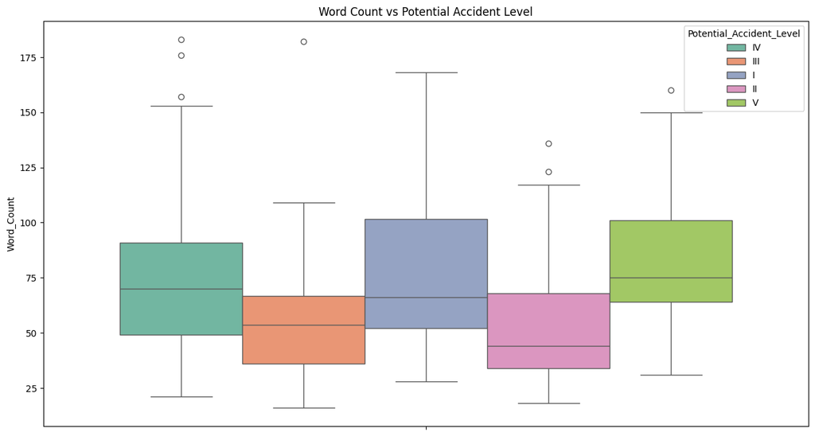

```python
#Word Count vs Potential Accident Level
plt.figure(figsize=(15,8))
sns.boxplot(df,y='Word_Count',hue='Potential_Accident_Level',palette='Set2');
plt.title('Word Count vs Potential Accident Level');
```

- Description of Levels I, IV and V in general longer than those of Levels II and III
- Longest description has around 200 words and belongs to Potential Accident Levels III and IV

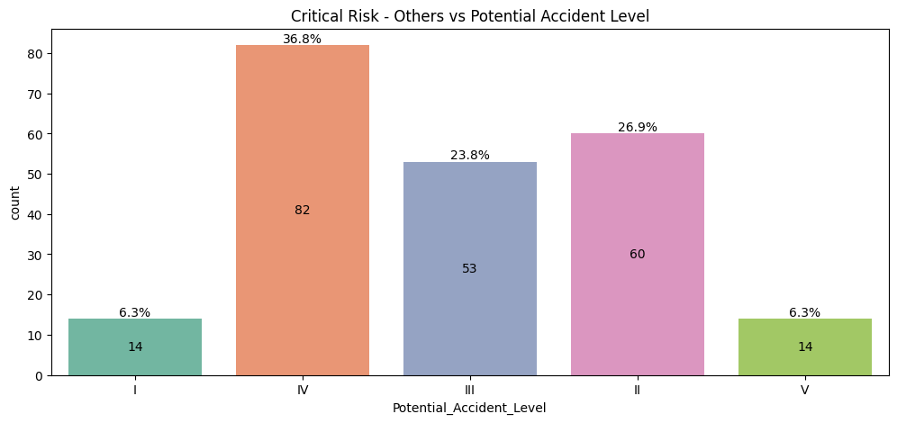

```python
#Others Critical Risk vs Potential Accident Level
#considering only Others as >50% of data has Critical Risk = 'Others'

others_risks = df[df['Critical_Risk'] == 'Others']


plt.figure(figsize = (12,5))
ax = sns.countplot(others_risks,x='Potential_Accident_Level',palette='Set2')

# Calculate percentages
total = len(others_risks['Potential_Accident_Level'])

# Add labels on the bars
for p in ax.patches:

    count = p.get_height()
    percentage = (count/total) * 100

    # Add count label in the center
    ax.text(p.get_x() + p.get_width()/2.,
            count/2.,
            f'{int(count)}',
            ha='center',
            va='center')

    # Add percentage label on top
    ax.text(p.get_x() + p.get_width()/2.,
            count,
            f'{percentage:.1f}%',
            ha='center',
            va='bottom')

plt.title(f"Critical Risk - Others vs Potential Accident Level");
```

## Text Preprocessing

#### Check for ASCII

```python
# Checking if there are any UTF-8 characters
def check_beyond_ascii(text):
    return all(ord(char) > 128 for char in text)

df['Has_non_ASCII'] = df['Description'].apply(check_beyond_ascii)

if((df['Has_non_ASCII'].unique()[0]==False) | (len(df['Has_non_ASCII'].unique())==2)):
    print(df['Has_non_ASCII'].unique(), ': There are no characters beyond the range of ASCII character set.')
else:
    print(df['Has_non_ASCII'].unique(), ': There are characters beyond the range of ASCII character set. Please remove them.')
df.drop('Has_non_ASCII', axis=1, inplace=True)
```

[output not shown]

#### Check for HTML tags

```python
# Checking if there are any HTML tags or URLs
def check_html_urls(text):
    check_pattern = re.compile(r'https?://\S+|www\.\S+|<[^>]+>')
    return bool(check_pattern.search(text))

# Assuming pp_data is a DataFrame with a 'Description' column
df['Has_HTML_URLs'] = df['Description'].apply(check_html_urls)
if((df['Has_HTML_URLs'].unique()[0]==False) | (len(df['Has_HTML_URLs'].unique())==2)):
    print(df['Has_HTML_URLs'].unique(), ': There are no HTML tags or URLs in the data.')
else:
    print(df['Has_HTML_URLs'].unique(), ': There are HTML tags or URLs in the data. Please remove them.')
df.drop('Has_HTML_URLs', axis=1, inplace=True)
```

```
[False] : There are no HTML tags or URLs in the data.
```

## Text Preprocessing

Below are the steps:

- Remove special characters
- Convert all to lower case
- Trim white spaces
- Remove stop words
- Apply Lemmatizer

```python
# Loading the Lemmatizer
lemmatizer = WordNetLemmatizer()


# map NLTK pos to wordnet POS tag
def get_wordnet_pos(tag):
    if tag.startswith('J'):
        return wordnet.ADJ
    elif tag.startswith('V'):
        return wordnet.VERB
    elif tag.startswith('N'):
        return wordnet.NOUN
    elif tag.startswith('R'):
        return wordnet.ADV
    else:
        return wordnet.NOUN


def preprocess_text(text):
    # Lowercasing the entire text
    text = text.lower()

    # remove extra whitespace
    text = " ".join(text.split())

    # Retaining only alphabetic characters
    text = ' '.join(re.compile(r'[a-z]+').findall(text))

    # Removing English Stopwords
    stopwords_list = set(stopwords.words('english'))

    words = word_tokenize(text)
    pos_tags = pos_tag(words)

    lemmatized_text = [lemmatizer.lemmatize(word, get_wordnet_pos(tag)) for word, tag in pos_tags if word.isalpha() and  word  not in  stopwords_list]

    return lemmatized_text
```

```python
# Applying the function to perform text preprocessing
# Save clean text in new column
df['Processed_Description'] = df['Description'].apply(lambda x: " ".join(preprocess_text(x)))
df.head(2)
```

|  | Date | Country | City | Industry_Sector | Accident_Level | Potential_Accident_Level | Gender | Employee_Type | Critical_Risk | Description | Year | Month | Day | Day_Name | Word_Count | Processed_Description |
| --- | --- | --- | --- | --- | --- | --- | --- | --- | --- | --- | --- | --- | --- | --- | --- | --- |
| 0 | 2016-01-01 | Country_01 | Local_01 | Mining | I | IV | Male | Third Party | Pressed | While removing the drill rod of the Jumbo 08 for maintenance, the supervisor proceeds to loosen the support of the intermediate centralizer to facilitate the removal, seeing this the mechanic supports… | 2016 | 1 | 1 | Friday | 80 | remove drill rod jumbo maintenance supervisor proceeds loosen support intermediate centralizer facilitate removal see mechanic support one end drill equipment pull hand bar accelerate removal moment b… |
| 1 | 2016-01-02 | Country_02 | Local_02 | Mining | I | IV | Male | Employee | Pressurized Systems | During the activation of a sodium sulphide pump, the piping was uncoupled and the sulfide solution was designed in the area to reach the maid. Immediately she made use of the emergency shower and was … | 2016 | 1 | 2 | Saturday | 54 | activation sodium sulphide pump piping uncoupled sulfide solution design area reach maid immediately make use emergency shower direct ambulatory doctor later hospital note sulphide solution gram liter |

## Wordclouds

```python
#Helper method to plot wordclouds
def plt_wordcloud(words,title):

    wordcloud = WordCloud(colormap='RdBu', background_color='white',
                        width=3000, height=2500).generate(words)

    plt.figure(figsize=(20, 20))
    plt.subplot(1, 2, 1)
    plt.imshow(wordcloud, interpolation='bilinear')
    plt.axis('off')
    plt.title(title)
```

```python
descriptions = ' '.join(df['Processed_Description'])
descriptions = ' '.join([word for word in descriptions.split()])
```

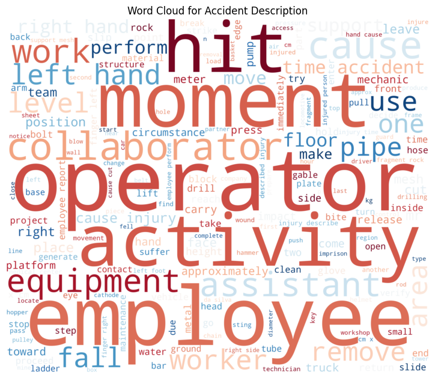

```python
plt_wordcloud(descriptions,'Word Cloud for Accident Description')
```

### POS Tag and Wordcloud

```python
description_list = df['Processed_Description'].tolist()
pos_tags = [pos_tag(word_tokenize(desc)) for desc in description_list]
df['POS_Tags'] = pos_tags
```

```python
# Flatten the list of POS tags
flat_pos_tags = [tag[0] for sublist in pos_tags for _, tag in sublist]

# Get all nouns and verbs
nouns = [word for word, tag in zip(word_tokenize(" ".join(description_list)), flat_pos_tags) if tag.startswith('N')]
verbs = [word for word, tag in zip(word_tokenize(" ".join(description_list)), flat_pos_tags) if tag.startswith('V')]
```

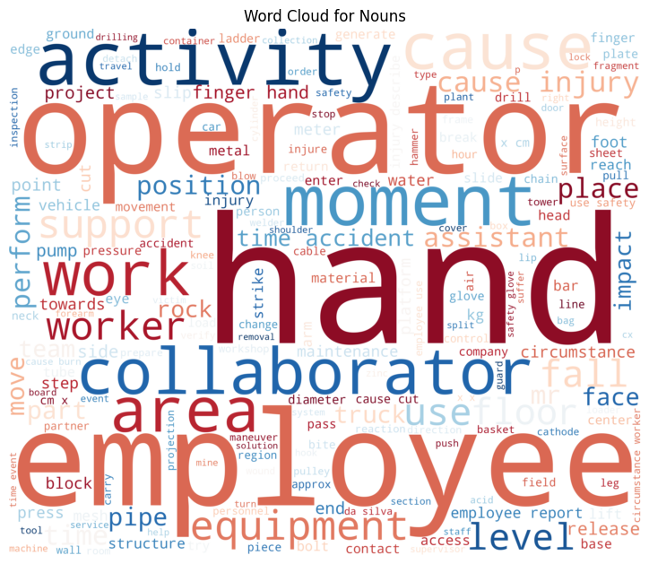

```python
plt_wordcloud(" ".join(nouns),'Word Cloud for Nouns')
```

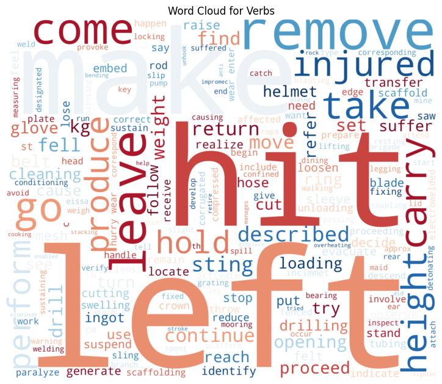

```python
plt_wordcloud(" ".join(verbs),'Word Cloud for Verbs')
```

**Observations**

- Most of the descriptions contain nouns like operator, employee - people involved in the accident
- Most of the descriptions contain verbs like hit, carry, injured, fell, drill which is most likely the action performed when the accident occured

## Save cleaned data

```python
#remove POS Tags column before saving the cleaned data
df.drop(['POS_Tags'],axis=1,inplace=True)
```

```python
#save the cleaned data
df.to_csv('/content/drive/My Drive/Capstone/accidents_cleaned_data.csv')
```

# Generate Word Embeddings

We will generate WordEmbeddings using 4 techniques in the below sections - TFIDF, Word2Vec, GloVe and Sentence Transformers

### Word Embedding using TF-IDF

We will generate TFIDF embedding using TfidfVectorizer with bigrams with size 1000. The final embedding will have 411 rows and 1000 columns

```python
tfidf_vectorizer = TfidfVectorizer(max_features=1000, stop_words='english', ngram_range=(2, 2))
tfidf_matrix = tfidf_vectorizer.fit_transform(description_list)
tfidf_df = pd.DataFrame(tfidf_matrix.toarray(), columns=tfidf_vectorizer.get_feature_names_out())

print(f'Shape of TF-IDF embedding : {tfidf_df.shape}')
```

```
Shape of TF-IDF embedding : (411, 1000)
```

#### Important bigrams

```python
# Display the most important bigrams
tfidf_scores = tfidf_df.sum(axis=0)
tfidf_scores_df = pd.DataFrame({'Feature': tfidf_vectorizer.get_feature_names_out(), 'TF-IDF Score': tfidf_scores})

top_features = tfidf_scores_df.sort_values(by='TF-IDF Score', ascending=False)

print("Top Bigrams:")
print(top_features.head(30))
```

```
Top Bigrams:
                                 Feature  TF-IDF Score
left hand                      left hand     14.356441
cause injury                cause injury     12.395551
right hand                    right hand     12.162649
time accident              time accident      8.930834
employee report          employee report      7.967478
finger left                  finger left      6.685114
medical center            medical center      5.826273
right leg                      right leg      5.046024
employee perform        employee perform      4.931248
left foot                      left foot      4.600435
generate injury          generate injury      4.320254
hand cause                    hand cause      4.289398
cm cm                              cm cm      4.250504
finger right                finger right      4.214805
cause cut                      cause cut      4.186705
hit right                      hit right      4.180391
described injury        described injury      4.125804
injury time                  injury time      3.918726
fragment rock              fragment rock      3.681042
injured person            injured person      3.636564
make use                        make use      3.631576
employee use                employee use      3.530755
lose balance                lose balance      3.486343
circumstance worker  circumstance worker      3.368135
use safety                    use safety      3.266699
middle finger              middle finger      3.249896
press finger                press finger      3.108314
support mesh                support mesh      3.072884
accident employee      accident employee      2.884980
cause irritation        cause irritation      2.829579
```

- most acccidents are likely to affect the employee's finger, hands, legs
- most are caused by hit, lose balance, irritation, etc

### Word Embedding using Word2Vec

We will use Word2Vec with size 1000 to generate embeddings. The final embedding will have 411 rows and 1000 columns

```python
# Creating a list of all words in our data
words_list = [item.split(" ") for item in df['Description'].values]
# Creating an instance of Word2Vec
vec_size = 1000
model_W2V = Word2Vec(words_list, vector_size = vec_size, min_count = 1, window=5, workers = 6)
# Checking the size of the vocabulary
print("Length of the Word2Vec vocabulary is", len(list(model_W2V.wv.key_to_index)))

# Retrieving the words present in the Word2Vec model's vocabulary
words = list(model_W2V.wv.key_to_index.keys())

# Retrieving word vectors for all the words present in the model's vocabulary
wvs = model_W2V.wv[words].tolist()

# Creating a dictionary of words and their corresponding vectors
word_vector_dict = dict(zip(words, wvs))

def average_vectorizer_Word2Vec(doc):
    # Initializing a feature vector for the news
    feature_vector = np.zeros((vec_size,), dtype="float64")

    # Creating a list of words in the news that are present in the model vocabulary
    words_in_vocab = [word for word in doc.split() if word in words]

    # adding the vector representations of the words
    for word in words_in_vocab:
        feature_vector += np.array(word_vector_dict[word])

    # Dividing by the number of words to get the average vector
    if len(words_in_vocab) != 0:
        feature_vector /= len(words_in_vocab)

    return feature_vector

# creating a dataframe of the vectorized documents
word2Vec_df = pd.DataFrame(df['Description'].apply(average_vectorizer_Word2Vec).tolist(), columns=['Feature '+str(i) for i in range(vec_size)])
print(f'Shape of Word2Vec embedding : {word2Vec_df.shape}')
```

```
Length of the Word2Vec vocabulary is 4756
Shape of Word2Vec embedding : (411, 1000)
```

### Word Embedding using GloVe

```python
# load the Stanford GloVe model
filename = '/content/drive/My Drive/Capstone/embed/word2vec-glove.6B.300d.txt'
#filename = "D:/Data/greatlearning/NLP/project/embed/glove.6B.100d.txt.word2vec"

glove_model = KeyedVectors.load_word2vec_format(filename, binary=False)
```

```python
# Checking the size of the vocabulary
print("Length of the GloVe vocabulary is", len(glove_model.index_to_key))
```

```
Length of the GloVe vocabulary is 400000
```

```python
glove_words = glove_model.index_to_key
glove_word_vector_dict = dict(zip(glove_model.index_to_key,list(glove_model.vectors)))
```

```python
vec_size=glove_model.vector_size
def average_vectorizer_GloVe(doc):
    # Initializing a feature vector for the news
    feature_vector = np.zeros((vec_size,), dtype="float64")

    # Creating a list of words in the news that are present in the model vocabulary
    words_in_vocab = [word for word in doc.split() if word in glove_words]

    # adding the vector representations of the words
    for word in words_in_vocab:
        feature_vector += np.array(glove_word_vector_dict[word])

    # Dividing by the number of words to get the average vector
    if len(words_in_vocab) != 0:
        feature_vector /= len(words_in_vocab)

    return feature_vector
```

```python
# creating a dataframe of the vectorized documents
glove_df = pd.DataFrame(df['Description'].apply(average_vectorizer_GloVe).tolist(), columns=['Feature '+str(i) for i in range(vec_size)])
print(f'Shape of GloVe embedding: {glove_df.shape}')
```

[output not shown]

### Word Embedding using Sentence Transformers

We will use all-MiniLM-L6-v2 sentence transformer model with size 384 to generate embeddings. The final embedding will have 411 rows and 384 column

```python
# defining the model
st_model = SentenceTransformer('sentence-transformers/all-MiniLM-L6-v2')
```

```python
# setting the device to GPU if available, else CPU
device = torch.device("cuda" if torch.cuda.is_available() else "cpu")
```

```python
# encoding the dataset
transformer_df = st_model.encode(df['Description'].to_list(), device=device, show_progress_bar=True)
```

```python
print(f'Shape of Sentence Transformer embedding: {transformer_df.shape}')
```

```
Shape of Sentence Transformer embedding: (411, 384)
```

# Model Building

## Approach and Metric Selection

The aim of the project is to use the accident description and predict its severity from a scale of Level I(least severe) to Level V(most severe)

So, this problem can be solved using MultiClass Classification algorithm.

There are two possible target features (Accident Level and Potential Accident Level).

Based on the EDA, we know Accident Level is highly imbalanced (74% of accidents are classified as Level I) and hence may not capture the actual severity like Potential Accident Level. Hence we will use Potential Accident Level as target.

We will explore the below traditional ML models on each of the above embeddings one at a time and compare the performances.

- Logistic Regression
- Decision Tree
- Random Forest
- Support Vector Classifier
- XGBoost Classifier

Models will be evaluated on Accuracy, Precision, Recall and F1 -Score against Train and Validation data Stratified Cross Validation will be performed to record Mean F1-scores across different folds.

These metrics will be compared and the best performing 3 models will be tuned using GridSearchCV. Post tuning,we will record their performance on test set using classification report, metrics and confusion metrics

We will use F1 score on the validation set as the evaluation metric for comparing models(because it is a multiclass classification problem and the target Potential Accident Level is moderately imbalanced)

**Note:**

- For each type of embedding, we will split into Train, Validation and Test sets
- All relevant independent features and respective embeddings will be considered.
- Dropped features include 'Date','Day_Name','Accident_Level','Description','Processed_Description'

## Helper Methods

```python
def evaluate_clf(model,model_label,X_train,y_train,X_valid,y_valid,cv_results):

    '''
        Evaluates the given model, against the given train data.
        Performs cross valiation against validation data

        Returns: the Pandas dataframe containing train and validation metrics
        and the mean CV score

    '''

    #define a base pipeline with the given model and fit it
    num_pipeline = Pipeline([
    ("impute", SimpleImputer(strategy="median")),
    ("scaler", StandardScaler()),
    ])


    cat_pipeline = Pipeline([
      ("impute", SimpleImputer(strategy="most_frequent")),
      ("encoder", OrdinalEncoder(handle_unknown = "use_encoded_value", unknown_value=-1))
    ])


    preprocessing = make_column_transformer(
    (num_pipeline, make_column_selector(dtype_include=np.number)),
    (cat_pipeline, make_column_selector(dtype_include=object)),
    )

    pipeline = Pipeline([
      ('preprocess',preprocessing),
      ('model',model)

    ])


    #fit the model and find predictions for train and validation sets
    pipeline.fit(X_train,y_train)


    #Perform CV
    skfold = StratifiedKFold(
        n_splits=FOLDS, shuffle=True, random_state=SEED
    )

    #use f1_score macro for evaluation of CV Scores
    cv_result = cross_val_score(
        estimator=pipeline, X=X_train, y=y_train, scoring="f1_macro", cv=skfold
    )
    cv_results.append(cv_result)


    y_preds_train = pipeline.predict(X_train)
    y_preds = pipeline.predict(X_valid)


    perf_df = pd.DataFrame(
        {'Accuracy Train':accuracy_score(y_train,y_preds_train),
         'Precision Train':precision_score(y_train,y_preds_train,average='macro'),
         'Recall Train':recall_score(y_train,y_preds_train,average='macro'),
         'F1 Score Train':f1_score(y_train,y_preds_train,average='macro'),
         'Accuracy Test':accuracy_score(y_valid,y_preds),
         'Precision Test':precision_score(y_valid,y_preds,average='macro'),
         'Recall Test':recall_score(y_valid,y_preds,average='macro'),
         'F1 Score Test':f1_score(y_valid,y_preds,average='macro'),
         'CV Score Mean':cv_result.mean()
         },
    index=[model_label])


    return perf_df
```

```python
def clf_model_performance(y_true,y_preds):

    '''
        Calculates the accuracy,precision, recall
        and f1 score for the given model against the true values
        and predictions provided.

        Returns: the metrics stored as a Pandas dataframe

    '''

    acc = accuracy_score(y_true,y_preds)
    precision = precision_score(y_true,y_preds,average='macro')
    recall = recall_score(y_true,y_preds,average='macro')
    f1 = f1_score(y_true,y_preds,average='macro')



    metrics_df = pd.DataFrame(
        {'Accuracy':acc,
         'Precision':precision,
         'Recall':recall,
         'F1 Score':f1,
        },
    index=[0])

    return metrics_df
```

```python
def clf_grid_search(model,param_grid,X_train,y_train):

    '''
        Performs Hyper Parameter tuning using sklearn GridSearchCV
        for the given model and parameter grid using 5 fold Cross Validation

        param_grid is a dictionary where keys are the parameter names
        for the given model and the values are list of possible values that
        need to be considered for the tuning

        Prints the Best Score and Parameters combination

        Returns: the best estimator as a result of GridSearchCV

    '''
    # use Stratified KFold CV with 5 folds
    skf = StratifiedKFold(n_splits=5)
    grid_search = GridSearchCV(estimator=model, param_grid=param_grid,
                          cv=skf, n_jobs=-1, verbose=2, scoring='accuracy')

    grid_search.fit(X_train, y_train)

    print('*'*70)
    print(f'Best Score: {grid_search.best_score_}')
    print('*'*70)
    print('Best parameters:')
    print(grid_search.best_params_)


    return grid_search.best_estimator_
```

## Prepare Data for Testing

```python
df.head(2)
```

|  | Date | Country | City | Industry_Sector | Accident_Level | Potential_Accident_Level | Gender | Employee_Type | Critical_Risk | Description | Year | Month | Day | Day_Name | Word_Count | Processed_Description |
| --- | --- | --- | --- | --- | --- | --- | --- | --- | --- | --- | --- | --- | --- | --- | --- | --- |
| 0 | 2016-01-01 | Country_01 | Local_01 | Mining | I | IV | Male | Third Party | Pressed | While removing the drill rod of the Jumbo 08 for maintenance, the supervisor proceeds to loosen the support of the intermediate centralizer to facilitate the removal, seeing this the mechanic supports… | 2016 | 1 | 1 | Friday | 80 | remove drill rod jumbo maintenance supervisor proceeds loosen support intermediate centralizer facilitate removal see mechanic support one end drill equipment pull hand bar accelerate removal moment b… |
| 1 | 2016-01-02 | Country_02 | Local_02 | Mining | I | IV | Male | Employee | Pressurized Systems | During the activation of a sodium sulphide pump, the piping was uncoupled and the sulfide solution was designed in the area to reach the maid. Immediately she made use of the emergency shower and was … | 2016 | 1 | 2 | Saturday | 54 | activation sodium sulphide pump piping uncoupled sulfide solution design area reach maid immediately make use emergency shower direct ambulatory doctor later hospital note sulphide solution gram liter |

```python
#define dataframe containing select columns from orginal data

feature_df = df.drop(['Date','Day_Name','Accident_Level','Potential_Accident_Level','Description','Processed_Description'],axis=1)
```

```python
feature_df.head(2)
```

|  | Country | City | Industry_Sector | Gender | Employee_Type | Critical_Risk | Year | Month | Day | Word_Count |
| --- | --- | --- | --- | --- | --- | --- | --- | --- | --- | --- |
| 0 | Country_01 | Local_01 | Mining | Male | Third Party | Pressed | 2016 | 1 | 1 | 80 |
| 1 | Country_02 | Local_02 | Mining | Male | Employee | Pressurized Systems | 2016 | 1 | 2 | 54 |

```python
#Static variables
SEED = 42
TEST_SIZE = 0.2
FOLDS = 5
```

## TF-IDF embedding on all models

#### Combine embeddings and other features

```python
X_tfidf = tfidf_df.join(feature_df) #TF-IDF embeddings + relevant features

#encode the target
y = df['Potential_Accident_Level']

encoder = OrdinalEncoder(handle_unknown='use_encoded_value',unknown_value=-1)
y = encoder.fit_transform(y.values.reshape(-1,1))
```

```python
#Split data into temp and test, further split temp to train and validation
X_temp, X_test_tfidf, y_temp, y_test_tfidf = train_test_split(X_tfidf,y, random_state = SEED, stratify = y, test_size=TEST_SIZE)
X_train_tfidf, X_valid_tfidf, y_train_tfidf, y_valid_tfidf = train_test_split(X_temp,y_temp, random_state = SEED,
                                                      stratify = y_temp, test_size = TEST_SIZE)
```

```python
models = []  # Empty list to store all the model names and model instances
cv_results_main = [] # Empty list to store CV results

main_perf_df = pd.DataFrame() # Empty DataFrame to store metrics
tfidf_perf_df = pd.DataFrame() # Empty DataFrame to store metrics

# Appending models into the list
models.append(("TFIDF Logistic Reg", LogisticRegression(random_state=SEED)))
models.append(("TFIDF DecisionTree", DecisionTreeClassifier(random_state=SEED)))
models.append(("TFIDF SVM",SVC()))
models.append(("TFIDF RandomForest", RandomForestClassifier(criterion='entropy',random_state=SEED)))
#models.append(("TFIDF GradientBoost", GradientBoostingClassifier(random_state=SEED)))
models.append(("TFIDF Xgboost", XGBClassifier(n_estimators=50,random_state=SEED)))


#evaluate each model and save metrics in common datatrame

for name,model in models:
    perf_df = evaluate_clf(model,name,X_train_tfidf,y_train_tfidf,X_valid_tfidf,y_valid_tfidf,cv_results_main)
    main_perf_df = pd.concat([main_perf_df,perf_df])
    tfidf_perf_df = pd.concat([tfidf_perf_df,perf_df])
```

#### Model performance on TF-IDF

```python
#display all metrics
#highight min and max values in each column
tfidf_perf_df.sort_values(by = ['F1 Score Test','CV Score Mean'],ascending=False
        ).style.highlight_max(color="lightgreen", axis=0).highlight_min(color="pink", axis=0)
```

|  | Accuracy Train | Precision Train | Recall Train | F1 Score Train | Accuracy Test | Precision Test | Recall Test | F1 Score Test | CV Score Mean |
| --- | --- | --- | --- | --- | --- | --- | --- | --- | --- |
| TFIDF Logistic Reg | 1.000000 | 1.000000 | 1.000000 | 1.000000 | 0.348485 | 0.355556 | 0.298304 | 0.310333 | 0.336414 |
| TFIDF DecisionTree | 1.000000 | 1.000000 | 1.000000 | 1.000000 | 0.272727 | 0.219372 | 0.258065 | 0.229976 | 0.233550 |
| TFIDF RandomForest | 1.000000 | 1.000000 | 1.000000 | 1.000000 | 0.257576 | 0.352235 | 0.207772 | 0.223620 | 0.275571 |
| TFIDF SVM | 0.866412 | 0.917886 | 0.748193 | 0.780828 | 0.363636 | 0.231303 | 0.238930 | 0.201176 | 0.225583 |
| TFIDF Xgboost | 0.996183 | 0.997753 | 0.997059 | 0.997389 | 0.242424 | 0.205466 | 0.193705 | 0.193571 | 0.190359 |

**Observations:**

- All models are overfit except SVM (mostly due to limited size of the data)
- Logistic Regression has the highest F1-score(31%) and Mean CV Score(33%)
- SVM and XGBoost are the least performing models on TF-IDF embeddings

## Word2Vec embedding on all models

#### Combine embeddings and other features

```python
X_w2vec = word2Vec_df.join(feature_df) #Word2Vec embeddings + relevant features
```

```python
#Split data into temp and test, further split temp to train and validation
X_temp, X_test_w2Vec, y_temp, y_test_w2Vec = train_test_split(X_w2vec,y, random_state = SEED, stratify = y, test_size=TEST_SIZE)
X_train_w2Vec, X_valid_w2Vec, y_train_w2Vec, y_valid_w2Vec = train_test_split(X_temp,y_temp, random_state = SEED,
                                                      stratify = y_temp, test_size = TEST_SIZE)
```

```python
models = []  # Empty list to store all the model names and model instances
cv_results_main = [] # Empty list to store CV results

#main_perf_df = pd.DataFrame() # Empty DataFrame to store metrics
word2Vec_perf_df = pd.DataFrame() # Empty DataFrame to store metrics

# Appending models into the list
models.append(("W2Vec Logistic Reg", LogisticRegression(random_state=SEED)))
models.append(("W2Vec DecisionTree", DecisionTreeClassifier(random_state=SEED)))
models.append(("W2Vec SVM",SVC()))
models.append(("W2Vec RandomForest", RandomForestClassifier(random_state=SEED)))
#models.append(("W2Vec GradientBoost", GradientBoostingClassifier(random_state=SEED)))
models.append(("W2Vec Xgboost", XGBClassifier(n_estimators=50,random_state=SEED)))


#evaluate each model and save metrics in common datatrame

for name,model in models:
    perf_df = evaluate_clf(model,name,X_train_w2Vec,y_train_w2Vec,X_valid_w2Vec,y_valid_w2Vec,cv_results_main)
    main_perf_df = pd.concat([main_perf_df,perf_df])
    word2Vec_perf_df = pd.concat([word2Vec_perf_df,perf_df])
```

#### Model performance on Word2Vec

```python
#display all metrics
#highight min and max values in each column
word2Vec_perf_df.sort_values(by = ['F1 Score Test','CV Score Mean'],ascending=False
        ).style.highlight_max(color="lightgreen", axis=0).highlight_min(color="pink", axis=0)
```

|  | Accuracy Train | Precision Train | Recall Train | F1 Score Train | Accuracy Test | Precision Test | Recall Test | F1 Score Test | CV Score Mean |
| --- | --- | --- | --- | --- | --- | --- | --- | --- | --- |
| W2Vec Xgboost | 1.000000 | 1.000000 | 1.000000 | 1.000000 | 0.393939 | 0.338629 | 0.318228 | 0.312261 | 0.244017 |
| W2Vec DecisionTree | 1.000000 | 1.000000 | 1.000000 | 1.000000 | 0.333333 | 0.241832 | 0.250924 | 0.241103 | 0.226927 |
| W2Vec Logistic Reg | 0.648855 | 0.711463 | 0.615709 | 0.645714 | 0.318182 | 0.219780 | 0.240265 | 0.227943 | 0.328800 |
| W2Vec RandomForest | 1.000000 | 1.000000 | 1.000000 | 1.000000 | 0.318182 | 0.201299 | 0.221248 | 0.206961 | 0.266129 |
| W2Vec SVM | 0.362595 | 0.232543 | 0.224606 | 0.159670 | 0.333333 | 0.165625 | 0.202674 | 0.118727 | 0.139057 |

**Observations:**

## GloVe embedding on all models

#### Combine embeddings and other features

```python
X_glove = glove_df.join(feature_df) #Glove embeddings + relevant features
```

```python
#Split data into temp and test, further split temp to train and validation
X_temp, X_test_glove, y_temp, y_test_glove = train_test_split(X_glove,y, random_state = SEED, stratify = y, test_size=TEST_SIZE)
X_train_glove, X_valid_glove, y_train_glove, y_valid_glove = train_test_split(X_temp,y_temp, random_state = SEED,
                                                      stratify = y_temp, test_size = TEST_SIZE)
```

```python
models = []  # Empty list to store all the model names and model instances
cv_results_main = [] # Empty list to store CV results

#main_perf_df = pd.DataFrame() # Empty DataFrame to store metrics
glove_perf_df = pd.DataFrame() # Empty DataFrame to store metrics

# Appending models into the list
models.append(("Glove Logistic Reg", LogisticRegression(random_state=SEED)))
models.append(("Glove DecisionTree", DecisionTreeClassifier(random_state=SEED)))
models.append(("Glove SVM",SVC()))
models.append(("Glove RandomForest", RandomForestClassifier(random_state=SEED)))
#models.append(("Glove GradientBoost", GradientBoostingClassifier(random_state=SEED)))
models.append(("Glove Xgboost", XGBClassifier(n_estimators=50,random_state=SEED)))


#evaluate each model and save metrics in common dataframe

for name,model in models:
    perf_df = evaluate_clf(model,name,X_train_glove,y_train_glove,X_valid_glove,y_valid_glove,cv_results_main)
    main_perf_df = pd.concat([main_perf_df,perf_df])
    glove_perf_df = pd.concat([glove_perf_df,perf_df])
```

#### Model performance on Glove

```python
#display all metrics
#highight min and max values in each column
glove_perf_df.sort_values(by = ['F1 Score Test','CV Score Mean'],ascending=False
        ).style.highlight_max(color="lightgreen", axis=0).highlight_min(color="pink", axis=0)
```

|  | Accuracy Train | Precision Train | Recall Train | F1 Score Train | Accuracy Test | Precision Test | Recall Test | F1 Score Test | CV Score Mean |
| --- | --- | --- | --- | --- | --- | --- | --- | --- | --- |
| Glove RandomForest | 1.000000 | 1.000000 | 1.000000 | 1.000000 | 0.484848 | 0.427778 | 0.393522 | 0.396498 | 0.281966 |
| Glove Logistic Reg | 0.927481 | 0.946150 | 0.947447 | 0.946647 | 0.378788 | 0.329470 | 0.325643 | 0.326526 | 0.278342 |
| Glove Xgboost | 1.000000 | 1.000000 | 1.000000 | 1.000000 | 0.378788 | 0.321508 | 0.317622 | 0.306841 | 0.301549 |
| Glove DecisionTree | 1.000000 | 1.000000 | 1.000000 | 1.000000 | 0.333333 | 0.283843 | 0.283402 | 0.280356 | 0.243387 |
| Glove SVM | 0.553435 | 0.583214 | 0.428556 | 0.444570 | 0.363636 | 0.330926 | 0.241604 | 0.215775 | 0.183752 |

**Observations:**

- All models are overfit except SVM (mostly due to limited size of the data)
- Random Forest has the highest F1-score(39%)
- XGBoost has the highest Mean CV Score (30%)
- SVM and Decision Tree are the least performing models on Glove embeddings

## Sentence Transformer embedding on all models

#### Combine embeddings and other features

```python
transformer_embed_df = pd.DataFrame(transformer_df) #ST embeddings + relevant features

X_st = transformer_embed_df.join(feature_df)
X_st.columns = X_st.columns.astype(str) #change int feature names to string names
```

```python
X_st.head(2)
```

|  | 0 | 1 | 2 | 3 | 4 | 5 | 6 | 7 | 8 | 9 | ... | Country | City | Industry_Sector | Gender | Employee_Type | Critical_Risk | Year | Month | Day | Word_Count |
| --- | --- | --- | --- | --- | --- | --- | --- | --- | --- | --- | --- | --- | --- | --- | --- | --- | --- | --- | --- | --- | --- |
| 0 | 0.003961 | 0.055743 | 0.062342 | -0.023735 | -0.044342 | 0.065095 | 0.056594 | 0.047838 | -0.016331 | 0.005694 | ... | Country_01 | Local_01 | Mining | Male | Third Party | Pressed | 2016.0 | 1.0 | 1.0 | 80.0 |
| 1 | -0.050723 | 0.013573 | 0.056986 | 0.005193 | -0.047872 | -0.008938 | 0.089332 | 0.065994 | -0.006914 | -0.080088 | ... | Country_02 | Local_02 | Mining | Male | Employee | Pressurized Systems | 2016.0 | 1.0 | 2.0 | 54.0 |

2 rows × 394 columns

```python
#Split data into temp and test, further split temp to train and validation
X_temp, X_test_st, y_temp, y_test_st = train_test_split(X_st,y, random_state = SEED, stratify = y, test_size=TEST_SIZE)
X_train_st, X_valid_st, y_train_st, y_valid_st = train_test_split(X_temp,y_temp, random_state = SEED,
                                                      stratify = y_temp, test_size = TEST_SIZE)
```

```python
models = []  # Empty list to store all the model names and model instances
cv_results_main = [] # Empty list to store CV results

#main_perf_df = pd.DataFrame() # Empty DataFrame to store metrics
transf_perf_df = pd.DataFrame() # Empty DataFrame to store metrics

# Appending models into the list
models.append(("ST Logistic Reg", LogisticRegression(random_state=SEED)))
models.append(("ST DecisionTree", DecisionTreeClassifier(random_state=SEED)))
models.append(("ST SVM",SVC(random_state=SEED)))
models.append(("ST RandomForest", RandomForestClassifier(random_state=SEED)))
#models.append(("ST GradientBoost", GradientBoostingClassifier(random_state=SEED)))
models.append(("ST Xgboost", XGBClassifier(n_estimators=50,random_state=SEED)))


#evaluate each model and save metrics in common datatrame

for name,model in models:
    perf_df = evaluate_clf(model,name,X_train_st,y_train_st,X_valid_st,y_valid_st, cv_results_main)
    main_perf_df = pd.concat([main_perf_df,perf_df])
    transf_perf_df = pd.concat([transf_perf_df,perf_df])
```

#### Model performance on Sentence Transformer

```python
#display all metrics
#highight min and max values in each column
transf_perf_df.sort_values(by = ['F1 Score Test','CV Score Mean'],ascending=False
        ).style.highlight_max(color="lightgreen", axis=0).highlight_min(color="pink", axis=0)
```

|  | Accuracy Train | Precision Train | Recall Train | F1 Score Train | Accuracy Test | Precision Test | Recall Test | F1 Score Test | CV Score Mean |
| --- | --- | --- | --- | --- | --- | --- | --- | --- | --- |
| ST Logistic Reg | 1.000000 | 1.000000 | 1.000000 | 1.000000 | 0.469697 | 0.415556 | 0.421523 | 0.413483 | 0.364433 |
| ST Xgboost | 1.000000 | 1.000000 | 1.000000 | 1.000000 | 0.409091 | 0.390870 | 0.356552 | 0.360519 | 0.324161 |
| ST SVM | 0.832061 | 0.918094 | 0.734113 | 0.780773 | 0.424242 | 0.396364 | 0.353216 | 0.342424 | 0.287357 |
| ST DecisionTree | 1.000000 | 1.000000 | 1.000000 | 1.000000 | 0.378788 | 0.322381 | 0.338370 | 0.328360 | 0.220041 |
| ST RandomForest | 1.000000 | 1.000000 | 1.000000 | 1.000000 | 0.378788 | 0.420907 | 0.309300 | 0.322527 | 0.294620 |

**Observations:**

- All models are overfit except SVM (mostly due to limited size of the data)
- Logistic Regression has the highest F1-score(41%) and Mean CV Score(36%)
- SVM, Decision Tree and Random Forest are the least performing models on Sentence Transformer embeddings

## Compare performance metrics

We will look at the performance metrics of all models across all embeddings. Top 3 performing models are selected for Hyper parameter tuning based on the F1-Score of the validation set

```python
#display all metrics
#highight min and max values in each column
main_perf_df.sort_values(by = ['F1 Score Test'],ascending=False
        ).style.highlight_max(color="lightgreen", axis=0).highlight_min(color="pink", axis=0)
```

|  | Accuracy Train | Precision Train | Recall Train | F1 Score Train | Accuracy Test | Precision Test | Recall Test | F1 Score Test | CV Score Mean |
| --- | --- | --- | --- | --- | --- | --- | --- | --- | --- |
| ST Logistic Reg | 1.000000 | 1.000000 | 1.000000 | 1.000000 | 0.469697 | 0.415556 | 0.421523 | 0.413483 | 0.364433 |
| Glove RandomForest | 1.000000 | 1.000000 | 1.000000 | 1.000000 | 0.484848 | 0.427778 | 0.393522 | 0.396498 | 0.281966 |
| ST Xgboost | 1.000000 | 1.000000 | 1.000000 | 1.000000 | 0.409091 | 0.390870 | 0.356552 | 0.360519 | 0.324161 |
| ST SVM | 0.832061 | 0.918094 | 0.734113 | 0.780773 | 0.424242 | 0.396364 | 0.353216 | 0.342424 | 0.287357 |
| ST DecisionTree | 1.000000 | 1.000000 | 1.000000 | 1.000000 | 0.378788 | 0.322381 | 0.338370 | 0.328360 | 0.220041 |
| Glove Logistic Reg | 0.927481 | 0.946150 | 0.947447 | 0.946647 | 0.378788 | 0.329470 | 0.325643 | 0.326526 | 0.278342 |
| ST RandomForest | 1.000000 | 1.000000 | 1.000000 | 1.000000 | 0.378788 | 0.420907 | 0.309300 | 0.322527 | 0.294620 |
| W2Vec Xgboost | 1.000000 | 1.000000 | 1.000000 | 1.000000 | 0.393939 | 0.338629 | 0.318228 | 0.312261 | 0.244017 |
| TFIDF Logistic Reg | 1.000000 | 1.000000 | 1.000000 | 1.000000 | 0.348485 | 0.355556 | 0.298304 | 0.310333 | 0.336414 |
| Glove Xgboost | 1.000000 | 1.000000 | 1.000000 | 1.000000 | 0.378788 | 0.321508 | 0.317622 | 0.306841 | 0.301549 |
| Glove DecisionTree | 1.000000 | 1.000000 | 1.000000 | 1.000000 | 0.333333 | 0.283843 | 0.283402 | 0.280356 | 0.243387 |
| W2Vec DecisionTree | 1.000000 | 1.000000 | 1.000000 | 1.000000 | 0.333333 | 0.241832 | 0.250924 | 0.241103 | 0.226927 |
| TFIDF DecisionTree | 1.000000 | 1.000000 | 1.000000 | 1.000000 | 0.272727 | 0.219372 | 0.258065 | 0.229976 | 0.233550 |
| W2Vec Logistic Reg | 0.648855 | 0.711463 | 0.615709 | 0.645714 | 0.318182 | 0.219780 | 0.240265 | 0.227943 | 0.328800 |
| TFIDF RandomForest | 1.000000 | 1.000000 | 1.000000 | 1.000000 | 0.257576 | 0.352235 | 0.207772 | 0.223620 | 0.275571 |
| Glove SVM | 0.553435 | 0.583214 | 0.428556 | 0.444570 | 0.363636 | 0.330926 | 0.241604 | 0.215775 | 0.183752 |
| W2Vec RandomForest | 1.000000 | 1.000000 | 1.000000 | 1.000000 | 0.318182 | 0.201299 | 0.221248 | 0.206961 | 0.266129 |
| TFIDF SVM | 0.866412 | 0.917886 | 0.748193 | 0.780828 | 0.363636 | 0.231303 | 0.238930 | 0.201176 | 0.225583 |
| TFIDF Xgboost | 0.996183 | 0.997753 | 0.997059 | 0.997389 | 0.242424 | 0.205466 | 0.193705 | 0.193571 | 0.190359 |
| W2Vec SVM | 0.362595 | 0.232543 | 0.224606 | 0.159670 | 0.333333 | 0.165625 | 0.202674 | 0.118727 | 0.139057 |

### Observation on model performance

```python
#save the performance metrics details
main_perf_df.to_csv('/content/drive/My Drive/Capstone/perf_df.csv',index=False)
```

## Hyper Param Tuning of Best Model

- We will use GridSearchCV to tune hyperparameters for the best performing 3 models
- Aim is to reduce overfit and increase F1-score of the respective models

### Helper method

```python
def tune_clf(model_label,model,X_train, y_train,X_valid,y_valid,param_grid=None):

    '''
        Helper method that will define and tune a the given model for the given
        train and validation set. Parameters are tuned using GridSearchCV against
        the given param grid

    '''

    #define a base pipeline and fit it
    num_pipeline = Pipeline([
    ("impute", SimpleImputer(strategy="median")),
    ("scaler", StandardScaler()),
    ])


    cat_pipeline = Pipeline([
      ("impute", SimpleImputer(strategy="most_frequent")),
      ("encoder", OrdinalEncoder(handle_unknown = "use_encoded_value", unknown_value=-1))
    ])


    preprocessing = make_column_transformer(
    (num_pipeline, make_column_selector(dtype_include=np.number)),
    (cat_pipeline, make_column_selector(dtype_include=object)),
    )

    pipeline = Pipeline([
      ('preprocess',preprocessing),
      ('model',model)

    ])

    pipeline.fit(X_train, y_train)

    #make predictions on both train and validation set
    y_preds_train = pipeline.predict(X_train)
    y_preds = pipeline.predict(X_valid)



    #calculate various performance metrics on base model
    train_df = clf_model_performance(y_train,y_preds_train)
    valid_df = clf_model_performance(y_valid,y_preds)

    print(f'{model_label} Base Training classification report\n')
    print(classification_report(y_train,y_preds_train))
    print('*'*70)
    print(f'{model_label} Base Validation classification report\n')
    print(classification_report(y_valid,y_preds))


    #Hyper param tuning and get the best model
    clf_best = clf_grid_search(pipeline,param_grid, X_train, y_train)

    #make predictions on both train and validation set
    #using the best tuned model
    y_preds_train = clf_best.predict(X_train)
    y_preds = clf_best.predict(X_valid)



    #calculate various performance metrics on best model
    train_df_best = clf_model_performance(y_train,y_preds_train)
    valid_df_best = clf_model_performance(y_valid,y_preds)

    print('*'*70)
    print(f'{model_label} Best Training classification report\n')
    print(classification_report(y_train,y_preds_train))
    print('*'*70)
    print(f'{model_label} Best Validation classification report\n')
    print(classification_report(y_valid,y_preds))

    #create a dataframe summarising performance across base and best models
    #for the given embedding

    perf_df = pd.concat([train_df.T,valid_df.T,train_df_best.T,valid_df_best.T],axis=1)

    perf_df.columns = [
    f"{model_label} Base Train",
    f"{model_label} Base Valid",
    f"{model_label} Best Train",
    f"{model_label} Best Valid",
   ]

    return perf_df, clf_best
```

### Tune Logistic Regression on Sentence Transformer embeddings

```python
lg_param_grid = [
    {'model__penalty':['l1','l2'],
    'model__C' : np.logspace(-4,4,20),
    'model__solver': ['lbfgs','newton-cg','liblinear'],
    'model__max_iter'  : np.arange(20,40,5)
}
]
lg_model = LogisticRegression(random_state = SEED)
comp_lg_df, lg_clf_best = tune_clf('ST Logistic Regression', lg_model, X_train_st, y_train_st,
                                   X_valid_st,y_valid_st,param_grid = lg_param_grid)
```

```
ST Logistic Regression Base Training classification report

              precision    recall  f1-score   support

         0.0       1.00      1.00      1.00        27
         1.0       1.00      1.00      1.00        61
         2.0       1.00      1.00      1.00        68
         3.0       1.00      1.00      1.00        88
         4.0       1.00      1.00      1.00        18

    accuracy                           1.00       262
   macro avg       1.00      1.00      1.00       262
weighted avg       1.00      1.00      1.00       262

ST Logistic Regression Base Validation classification report

              precision    recall  f1-score   support

         0.0       0.67      0.57      0.62         7
         1.0       0.47      0.47      0.47        15
         2.0       0.50      0.71      0.59        17
         3.0       0.44      0.36      0.40        22
         4.0       0.00      0.00      0.00         5

    accuracy                           0.47        66
   macro avg       0.42      0.42      0.41        66
weighted avg       0.45      0.47      0.46        66

Fitting 5 folds for each of 480 candidates, totalling 2400 fits
Best Score: 0.41596516690856317
Best parameters:
{'model__C': 0.033598182862837805, 'model__max_iter': 20, 'model__penalty': 'l2', 'model__solver': 'newton-cg'}
ST Logistic Regression Best Training classification report

              precision    recall  f1-score   support

         0.0       1.00      1.00      1.00        27
         1.0       1.00      0.98      0.99        61
         2.0       1.00      1.00      1.00        68
         3.0       0.99      1.00      0.99        88
         4.0       1.00      1.00      1.00        18

    accuracy                           1.00       262
   macro avg       1.00      1.00      1.00       262
weighted avg       1.00      1.00      1.00       262

ST Logistic Regression Best Validation classification report

              precision    recall  f1-score   support

         0.0       0.67      0.57      0.62         7
         1.0       0.47      0.47      0.47        15
         2.0       0.46      0.65      0.54        17
         3.0       0.45      0.41      0.43        22
         4.0       0.00      0.00      0.00         5

    accuracy                           0.47        66
   macro avg       0.41      0.42      0.41        66
weighted avg       0.44      0.47      0.45        66
```

```python
comp_lg_df.T
```

|  | Accuracy | Precision | Recall | F1 Score |
| --- | --- | --- | --- | --- |
| ST Logistic Regression Base Train | 1.000000 | 1.000000 | 1.000000 | 1.000000 |
| ST Logistic Regression Base Valid | 0.469697 | 0.415556 | 0.421523 | 0.413483 |
| ST Logistic Regression Best Train | 0.996183 | 0.997753 | 0.996721 | 0.997217 |
| ST Logistic Regression Best Valid | 0.469697 | 0.408333 | 0.418849 | 0.409442 |

**Observations**

- Hyperparam tuning has not helped to reduce the amount of overfit significantly
- F1- Score Test Metrics before tuning : 41%
- F1- Score Test Metrics after tuning : 40%

### Tune Random Forest on Glove

```python
rf_param_grid = {
    'model__n_estimators':np.arange(5,10,1),
    'model__max_depth': np.arange(3,5,1),
   'model__min_samples_leaf': np.arange(4,8,1)

}
rf_model = RandomForestClassifier(n_estimators=50, criterion = 'entropy', random_state=SEED)
comp_rf_df, rf_clf_best = tune_clf('Glove RandomForest', rf_model, X_train_glove, y_train_glove,
                                            X_valid_glove, y_valid_glove, param_grid = rf_param_grid)
```

```
Glove RandomForest Base Training classification report

              precision    recall  f1-score   support

         0.0       1.00      1.00      1.00        27
         1.0       1.00      1.00      1.00        61
         2.0       1.00      1.00      1.00        68
         3.0       1.00      1.00      1.00        88
         4.0       1.00      1.00      1.00        18

    accuracy                           1.00       262
   macro avg       1.00      1.00      1.00       262
weighted avg       1.00      1.00      1.00       262

Glove RandomForest Base Validation classification report

              precision    recall  f1-score   support

         0.0       0.67      0.57      0.62         7
         1.0       0.38      0.33      0.36        15
         2.0       0.38      0.35      0.36        17
         3.0       0.45      0.64      0.53        22
         4.0       0.00      0.00      0.00         5

    accuracy                           0.44        66
   macro avg       0.38      0.38      0.37        66
weighted avg       0.41      0.44      0.42        66

Fitting 5 folds for each of 40 candidates, totalling 200 fits
Best Score: 0.3700290275761974
Best parameters:
{'model__max_depth': 4, 'model__min_samples_leaf': 4, 'model__n_estimators': 7}
Glove RandomForest Best Training classification report

              precision    recall  f1-score   support

         0.0       0.95      0.70      0.81        27
         1.0       0.77      0.66      0.71        61
         2.0       0.66      0.74      0.69        68
         3.0       0.63      0.82      0.71        88
         4.0       0.00      0.00      0.00        18

    accuracy                           0.69       262
   macro avg       0.60      0.58      0.58       262
weighted avg       0.66      0.69      0.67       262

Glove RandomForest Best Validation classification report

              precision    recall  f1-score   support

         0.0       0.25      0.14      0.18         7
         1.0       0.45      0.33      0.38        15
         2.0       0.25      0.29      0.27        17
         3.0       0.39      0.55      0.45        22
         4.0       0.00      0.00      0.00         5

    accuracy                           0.35        66
   macro avg       0.27      0.26      0.26        66
weighted avg       0.32      0.35      0.33        66
```

```python
comp_rf_df.T
```

|  | Accuracy | Precision | Recall | F1 Score |
| --- | --- | --- | --- | --- |
| Glove RandomForest Base Train | 1.000000 | 1.000000 | 1.000000 | 1.000000 |
| Glove RandomForest Base Valid | 0.439394 | 0.375579 | 0.378813 | 0.372893 |
| Glove RandomForest Best Train | 0.690840 | 0.601741 | 0.582583 | 0.584758 |
| Glove RandomForest Best Valid | 0.348485 | 0.268328 | 0.263153 | 0.257907 |

**Observations**

- Hyperparam tuning has helped to reduce the amount of overfit significantly
- F1- Score Test Metrics before tuning : 37%
- F1- Score Test Metrics after tuning : 25%

### Tune XGBoost on Sentence Transformer embeddings

```python
xgb_param_grid = {
    'model__learning_rate': np.arange(0.05,0.15,0.05),
    'model__n_estimators': [5,8,10],
    'model__max_depth': [3,4],
    'model__max_leaf_nodes': [5,10,15],
}
xgb_model = XGBClassifier(n_estimators=50, random_state=SEED)
comp_xgb_df, xgb_clf_best = tune_clf('ST XGBoost',xgb_model, X_train_st, y_train_st,
                                             X_valid_st,y_valid_st,param_grid = xgb_param_grid)
```

```
ST XGBoost Base Training classification report

              precision    recall  f1-score   support

         0.0       1.00      1.00      1.00        27
         1.0       1.00      1.00      1.00        61
         2.0       1.00      1.00      1.00        68
         3.0       1.00      1.00      1.00        88
         4.0       1.00      1.00      1.00        18

    accuracy                           1.00       262
   macro avg       1.00      1.00      1.00       262
weighted avg       1.00      1.00      1.00       262

ST XGBoost Base Validation classification report

              precision    recall  f1-score   support

         0.0       0.75      0.43      0.55         7
         1.0       0.40      0.53      0.46        15
         2.0       0.30      0.41      0.35        17
         3.0       0.50      0.41      0.45        22
         4.0       0.00      0.00      0.00         5

    accuracy                           0.41        66
   macro avg       0.39      0.36      0.36        66
weighted avg       0.42      0.41      0.40        66

Fitting 5 folds for each of 36 candidates, totalling 180 fits
Best Score: 0.35478955007256896
Best parameters:
{'model__learning_rate': 0.1, 'model__max_depth': 3, 'model__max_leaf_nodes': 5, 'model__n_estimators': 10}
ST XGBoost Best Training classification report

              precision    recall  f1-score   support

         0.0       1.00      0.89      0.94        27
         1.0       1.00      0.97      0.98        61
         2.0       0.96      0.96      0.96        68
         3.0       0.93      0.99      0.96        88
         4.0       1.00      0.94      0.97        18

    accuracy                           0.96       262
   macro avg       0.98      0.95      0.96       262
weighted avg       0.96      0.96      0.96       262

ST XGBoost Best Validation classification report

              precision    recall  f1-score   support

         0.0       0.67      0.29      0.40         7
         1.0       0.33      0.33      0.33        15
         2.0       0.25      0.29      0.27        17
         3.0       0.33      0.41      0.37        22
         4.0       0.00      0.00      0.00         5

    accuracy                           0.32        66
   macro avg       0.32      0.26      0.27        66
weighted avg       0.32      0.32      0.31        66
```

```python
comp_xgb_df.T
```

|  | Accuracy | Precision | Recall | F1 Score |
| --- | --- | --- | --- | --- |
| ST XGBoost Base Train | 1.000000 | 1.000000 | 1.000000 | 1.000000 |
| ST XGBoost Base Valid | 0.409091 | 0.390870 | 0.356552 | 0.360519 |
| ST XGBoost Best Train | 0.961832 | 0.976283 | 0.949013 | 0.961573 |
| ST XGBoost Best Valid | 0.318182 | 0.316667 | 0.264451 | 0.274190 |

**Observations**

- Hyperparam tuning has helped to reduce the amount of overfit
- F1- Score Test Metrics before tuning : 36%
- F1- Score Test Metrics after tuning : 27%

## Evaluate best models on test dataset

We will evaluate the performance of each of the 3 tuned models against the test data

We will look at the below performance metrics for each tuned model:

- Classification report
- Performance Summary containing Accuracy,Precision,Recall,F1 Score
- Confusion Matrix

### Helper Methods

```python
def clf_test(model, model_label, X_test, y_test):

    '''
      Print the performance metrics, classification report and
      confusion matrix for the given model and dataset

    '''


    y_pred = model.predict(X_test)


    test_df = clf_model_performance(y_test,y_pred)


    ConfusionMatrixDisplay.from_predictions(y_test,y_pred,cmap='Blues',
                                      colorbar=False,display_labels = ['I','II','III','IV','V']
                                        );
    plt.title(f'{model_label} Test Set Confusion Matrix');

    print('*'*70)
    print(f'\n{model_label} Test Set Classification Report')
    print('*'*70)


    print(classification_report(y_test,y_pred))
    print('*'*70)



    return test_df
```

### Performance of Logistic Regression on Sentence Transformer

```
ST Logistic Regression Test Set Classification Report
              precision    recall  f1-score   support

         0.0       0.67      0.44      0.53         9
         1.0       0.17      0.11      0.13        19
         2.0       0.27      0.48      0.34        21
         3.0       0.48      0.46      0.47        28
         4.0       0.00      0.00      0.00         6

    accuracy                           0.35        83
   macro avg       0.32      0.30      0.30        83
weighted avg       0.34      0.35      0.33        83
```

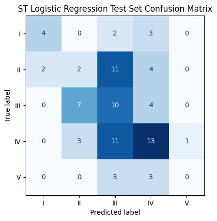

```python
lg_st_perf_df = clf_test(lg_clf_best,'ST Logistic Regression',X_test_st,y_test_st)
```

### Performance of Random Forest on Glove

```
Glove Random Forest Test Set Classification Report
              precision    recall  f1-score   support

         0.0       1.00      0.44      0.62         9
         1.0       0.33      0.32      0.32        19
         2.0       0.25      0.29      0.27        21
         3.0       0.38      0.50      0.43        28
         4.0       0.00      0.00      0.00         6

    accuracy                           0.36        83
   macro avg       0.39      0.31      0.33        83
weighted avg       0.38      0.36      0.35        83
```

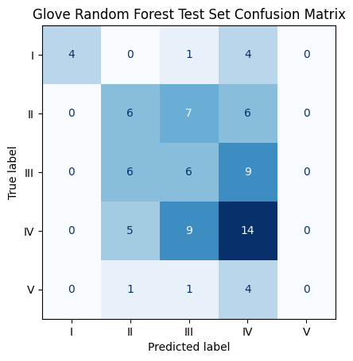

```python
rf_glove_perf_df = clf_test(rf_clf_best,'Glove Random Forest',X_test_glove,y_test_glove)
```

### Performance of XGBoost on Sentence Trasnformer

```
ST XGBoost Test Set Classification Report
              precision    recall  f1-score   support

         0.0       0.71      0.56      0.63         9
         1.0       0.43      0.32      0.36        19
         2.0       0.37      0.33      0.35        21
         3.0       0.41      0.61      0.49        28
         4.0       0.50      0.17      0.25         6

    accuracy                           0.43        83
   macro avg       0.49      0.40      0.42        83
weighted avg       0.44      0.43      0.42        83
```

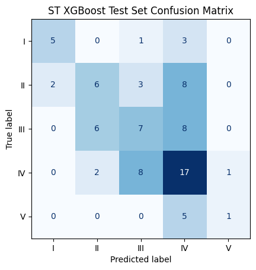

```python
xgb_st_perf_df = clf_test(xgb_clf_best,'ST XGBoost', X_test_st, y_test_st)
```

```python
final_perf_df = pd.concat([lg_st_perf_df,rf_glove_perf_df,xgb_st_perf_df])
final_perf_df.index = ['ST Logistic Regression', 'Glove Random Forest', 'ST XGBoost']


print('*'*70)
print('Summary of performance after hyper param tuning')
print('*'*70)
final_perf_df
```

```
Summary of performance after hyper param tuning
```

|  | Accuracy | Precision | Recall | F1 Score |
| --- | --- | --- | --- | --- |
| ST Logistic Regression | 0.349398 | 0.317017 | 0.298037 | 0.295984 |
| Glove Random Forest | 0.361446 | 0.392342 | 0.309190 | 0.327429 |
| ST XGBoost | 0.433735 | 0.485182 | 0.395698 | 0.416278 |

### Remarks

- XGBoost on Sentence Transformer embedding is the best performing model after hyper param tuning with F1 Score is 41% on the test set
- Random Forest on Glove embedding is next with F1 Score of 32%
- Least performing model is Logistic Regression on Sentence Transformer embedding with F1 Score of 29%
- Mis-classification is highest for Potential Accident Levels III and IV among all models but mostly in Logistic Regression on Sentence Transformer embedding
- Results can be improved by obtaining more training data (if feasible) and including advanced techniques like deep learning which can interpret the contextual information in accident description in a better way
- Another option is to use SMOTE to handle data imbalance or use data augmentation (NLP augmentation) to increase model performance